# The current practices of meta-analyses using animal models, and underappreciated opportunities using advanced methods: multilevel models and robust variance estimation

Electronic Supplementary Material

Yefeng Yang, Shinichi Nakagawa, Malgorzata Lagisz

May 2022

# Loading packages

Load the necessary R packages for data manipulation, visualizations and model implementation. Note that if your R does not have the following packages, you need to install them by using install.packages() for CRAN packages or devtools::install_github() for those archived on github repositories: **tidyverse**, **knitr**, **DT**, **readxl**, **metafor**, **clubSandwich**, **orchaRd**, **MuMIn**, **patchwork**, **GoodmanKruskal**, **networkD3**, **ggplot2**, **ggsignif**, **visdat**, **ggalluvial**, **ggthemr**, **cowplot**, **grDevices**, **png**, **grid**, **gridGraphics**, **pander**, **formatR**.

```r
# ggthemr needs to be downloaded from a github repo
# devtools::install_github('Mikata-Project/ggthemr', force = TRUE)
pacman::p_load(tidyverse, knitr, here, DT, readxl, metafor, clubSandwich, orchaRd,
    MuMIn, patchwork, GoodmanKruskal, networkD3, ggplot2, ggsignif, visdat, ggalluvial,
    ggthemr, cowplot, grDevices, png, grid, gridGraphics, pander, formatR)

# custom function for extracting mean and CI from each metafor model
estimates.CI <- function(model) {
    db.mf <- data.frame(round(model$b, 3), row.names = 1:nrow(model$b))
    db.mf <- cbind(db.mf, round(model$ci.lb, 3), round(model$ci.ub, 3), row.names(model$b))
    names(db.mf) <- c("mean", "lower", "upper", "estimate")
    return(db.mf[, c("estimate", "mean", "lower", "upper")])
}
```

# Why animal meta-analyses need advanced methods

We profiled the current practices of meta-analyses using animal data by mapping the statistical issues and approaches from papers published over the last 10 years (2011 – 2021). Our survey showed that researchers in animal meta-analyses mainly use traditional meta-analytic techniques (i.e., fixed- and random-effects models) for evidence synthesis (see main text for detailed survey results). Animal meta-analyses often combine studies with different species or strains, experimental designs (e.g., different ages and sex of the animal), multiple outcomes, multiple trials, each with multiple arms. These complex animal data structures often bring two statistical issues: **statistical dependence** and **multiple sources of heterogeneity**, which may lead to unreliable meta-analytic evidence (e.g., inflation of p-value) and limit our ability to provide novel meta-analytic insights into a given research field.

However, the traditional meta-analytic techniques are very limited in addressing the two issues. In the framework of multilevel model, the dependence and heterogeneity can be directly modeled. In the main text, we explain the concepts, rationale, and examples of the multilevel meta-analytic model. As a complementary to the theory of the multilevel model outlined in the main text, here, we provide a easy-to-implement tutorial to showcase how to conduct animal meta-analyses within the framework of multilevel model. We also illustrate how to implement other underappreciated methods, such as meta-analysis of variation, robust variance estimation. We encourage future ‘animal’ meta-analysts to modify the sample R code to undertake their own animal meta-analyses toward to draw more robust biological (neurological) inferences, new biological insights, and better animal-to-human translation.

# How to implement advanced meta-analytic techniques

This online tutorial contains two parts:

**Part I: Animal meta-analyses within the multilevel model framework**

In Part I, we reproduce a typical animal meta-analyses conducted by Ramsteijn et al. (2020), who employed the traditional meta-analytic techniques (i.e., random-effects model; see 6.1 in the main text). We use this dataset as the worked example to (1) show how failure to account for non-independence using traditional meta-analytic technique might lead to spurious conclusions，and (2) showcase the implementation of the multilevel meta-analytic framework (sections 6 to 8 in the main text).

Part I consists of 5 procedures. In procedure 1, we show how to use R coding to fit a traditional meta-analytic model, by which we expect you to get familiar with coding/syntax based implementation of meta-analytic models and corresponding model outputs:

**1. Fit a random-effects meta-analytic model**

By building upon the random-effects meta-analytic model (procedure 1), we illustrate the multilevel models related procedures. We recommend researchers to employ these procedures as default analytic pipelines when conducting animal meta-analysis:

**2. Fit a multilevel meta-analytic model to estimate overall pooled effect**

**3. Partition heterogeneity among effect size using the multilevel model**

**4. Fit multilevel meta-regressions to explain heterogeneity and estimate moderator effects**

**5. Test publication bias**

**Part II: Complimentary analysis with other advanced methods to handle more complex animal structure**

In Part II, we use a more complex animal dataset to show the implementation of the extended methods outlined in section 9 in the main text. This dataset comes from one of our published neuroscience meta-analysis (Lagisz et al., 2020). Methods implemented in Part II are not mandatory procedures for performing an animal meta-analysis, but following them can make an animal meta-analysis statistically more sound (more reliable model coefficients and statistical inferences). These extended methods includes：

**6. Select an appropriate random-effect structure**

**7. Fit multi-moderator multilevel meta-regression models**

**8. Construct variance-covariance matrix to account for correlated/non-independent error**

**9. Make cluster-robust model inferences**

Following section broadly aligns with the order of subheadings of our main text. For each procedure within Part I and Part II, we first briefly explain the necessary statistical concepts and rationale (detailed theoretical explanations can be found in the main text). Second, we use existing R packages and custom functions to show the implementation of each procedure.

# 1. Fit a random-effect meta-analytic model

We use the animal dataset provided by Ramsteijn et al. (2020) as our first worked example. This dataset comes from one of the meta-analyses included in our survey (Ramsteijn et al., 2020), where the authors examined the effect of perinatal selective serotonin re-uptake inhibitor (SSRI) exposure and behavioural phenotype of animals (e.g., exploration, learning, stress copying, social behaviour, sensory processing). We choose one of the subsets (sensory processing) to show the implementation.

## 1.1 Load the dataset of Ramsteijn et al. (2020)

### Table S1

A list of studies included in the work example and corresponding coded variables.

```r
### import dataset we only use a subset from the loaded dataset - sheet name =
### Sensory_processing
dat_sensory <- read_excel(here("data", "Ramsteijn_2020.xlsx"), sheet = "Sensory_processing",
    col_names = TRUE)

# library(ape) tree <- read.tree(here('data','tree_all.tre'))
# is.binary.tree(tree) #TRUE is.ultrametric(tree) #TRUE plot(tree, cex=0.8)
# #plot with branch lengths CorMatrix_all <- vcv(tree, corr=TRUE)



### show the demographics of the dataset
t1 <- dat_sensory %>%
    DT::datatable(rownames = FALSE, width = "100%", options = list(dom = "t", scrollY = "700px",
        pageLength = 20))  #, pageLength = 2
t1
```

| Order | Study_ID | Year | Comparison | Species | SSRI | age | age_new | duration of test (sec) | Test | Measure | Factor (1=efficient sensory processing, -1=opposite) | Sex | Stress | Window | SSRI_Mean | SSRI_SD | SSRI_Nadj | Vehicle_Mean | Vehicle_SD | Vehicle_Nadj | units | * Test abbreviation | In full | Count |
| --- | --- | --- | --- | --- | --- | --- | --- | --- | --- | --- | --- | --- | --- | --- | --- | --- | --- | --- | --- | --- | --- | --- | --- | --- |
| 1 | Khatri 2014 | 2014 |  | rat | CIT | 80 | 80 | 60 | OI | Contacts new vs old scent | 1 | both | No | lactation | 1.5 | 1.42232204510793 | 70 | 2.22 | 1.31624465810882 | 77 |  | ATRD | Auditory temporal rate discrimination | 2 |
| 2 | Kiryanova 2014 | 2014 |  | mouse | FLX | 115 | 115 |  | PPI | % inhibition | 1 | male | No | both | 61.6 | 11.2 | 16 | 60.6 | 14.8 | 16 | % | GC | Gap crossing | 1 |
| 3 | Ko 2014 | 2014 |  | rat | FLX | 64 | 64 |  | PPI | % inhibition | 1 | male | No | lactation | 11.96 | 19.9686955007081 | 8 | 38.59 | 15.3583592873718 | 8 | % | OI | Olfactory investigation | 1 |
| 4 | Kroeze 2016 | 2016 |  | rat | FLX | 21 | 21 |  | PPI | % inhibition | 1 | male | No | both | 5.88 | 18.3597385602301 | 12 | -5.29 | 16.48 | 16 |  | PPI | Prepulse inhibition | 13 |
| 5 | Lee 2009 | 2009 |  | rat | FLX | 33 | 33 | 60 | GR | Maximum crossable distance | 1 | both | No | lactation | 4.58 | 1.21243556529821 | 12 | 7.09 | 0.852056336165631 | 15 | cm |  |  |  |
| 6 | McAllister 2012 | 2012 |  | mouse | FLX | 121 | 121 |  | PPI | % inhibition | 1 | female | No | both | 57.8 | 11.8 | 16 | 51.6 | 19.3 | 17 | % |  |  |  |
| 7 | Vartazarmian 2005 | 2005 | Male | guinea pig | FLX | 63 | 63 |  | PPI | % inhibition | 1 | male | No | pregnancy | 56.28 | 23.9384418874746 | 10 | 58.18 | 11.466176346106 | 12 | % |  |  |  |
| 8 | Vartazarmian 2005 | 2005 | Female | guinea pig | FLX | 63 | 63 |  | PPI | % inhibition | 1 | female | No | pregnancy | 63.4 | 5.56560868189634 | 10 | 56.35 | 12.1936376852849 | 12 | % |  |  |  |
| 9 | Zhou 2015 | 2015 | Male | rat | CIT | 60 | 60 |  | ATRD | discrimination threshold | -1 | male | No | lactation | -8.75 | 0.852056336165634 | 15 | -7.35 | 0.762102355330308 | 12 | pps |  |  |  |
| 10 | Zhou 2015 | 2015 | Female | rat | CIT | 60 | 60 |  | ATRD | discrimination threshold | -1 | female | No | lactation | -7.57 | 0.823164625090266 | 14 | -7.29 | 0.813326502703557 | 15 | pps |  |  |  |

[output cut: 7 more lines]

```r
# dat_sensory %>% kableExtra::kbl() %>% kableExtra::kable_paper() %>%
# kableExtra::kable_styling('striped', position = 'left')
```

```r
### draw an alluvial plot to show the heterogeneous experimental designs of the
### studies included in the meta-analysis
freq <- as.data.frame(table(dat_sensory$Species, dat_sensory$Sex, dat_sensory$Test,
    dat_sensory$SSRI)) %>%
    rename(Species = Var2, Sex = Var4, Test = Var1, SSRI = Var3, )  #make a dataframe of frequencies for four selected variables
is_alluvia_form(as.data.frame(freq), axes = 1:4, silent = TRUE)

alluvil_plot <- ggplot(data = freq, aes(axis2 = Species, axis4 = Sex, axis1 = Test,
    axis3 = SSRI, y = Freq)) + geom_alluvium(aes(fill = Test, colour = Test)) + geom_flow() +
    geom_stratum() + geom_text(stat = "stratum", aes(label = after_stat(stratum))) +
    theme_void() + theme(legend.position = "none", plot.title = element_text(hjust = 0,
    vjust = 3), axis.title.x = element_text(), axis.text.x = element_text(face = "bold"),
    plot.margin = unit(c(1, 1, 0, 1), "cm")) + scale_x_discrete(limits = c("Species",
    "Sex", "Test method", "Exposure"), position = "top")
# save fig as .png png(filename = './alluvil_plot.png', width = 8, height = 4,
# units = 'in', type = 'windows', res = 400) alluvil_plot dev.off()
```

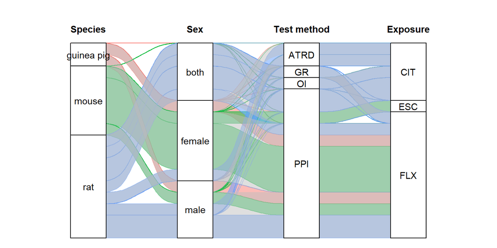

```r
alluvil_plot
```

### Figure S1

Heterogeneous experimental designs of primary studies included in the work example: relationship/nestedness between study species, sex, behavioural assay, and types of exposure (SSRIs).

## 1.2 Fit a random-effects model

Ramsteijn et al. (2020) used standardized mean differences (SMD) as the effect size metric to quantify the effect of SSRI exposure on animals’ sensory processing. Then Ramsteijn et al. (2020) conducted a random-effects meta-analysis to estimate the overall effect of SSRI and a series of subgroup analyses to examine how different moderators affect the magnitude of the effect of SSRI. Below, we reproduce Ramsteijn et al. (2020)’s analyses using their analytic pipelines (i.e., the traditional meta-analytic model).

### Effect size calculations

```
SMD <- escalc(measure = "SMD", # standardised mean difference should be calculated (alternative effect sizes: "ROM" – lnRR, "CVR" – lnCVR, "VR" – lnVR; see below);
              m1i = SSRI_Mean, # mean of treatment group (SSRI);
              m2i = Vehicle_Mean, # mean of control group (Vehicle);
              sd1i = SSRI_SD, # standard deviation of treatment group;
              sd2i = Vehicle_SD, # standard deviation of control group;
              n1i = SSRI_Nadj, # sample size of treatment group;
              n2i = Vehicle_Nadj, # sample size of control group;
              data = dat_sensory, # dataset of our work example;
              append = FALSE)
```

```r
### lets calculate SMD
SMD <- metafor::escalc(measure = "SMD", # standardised mean difference should be calculated (alternative effect sizes: "ROM" – lnRR, "CVR" – lnCVR, "VR" – lnVR; see below)
                        m1i = SSRI_Mean, # mean of treatment group (SSRI)
                        m2i = Vehicle_Mean, # mean of control group (Vehicle)
                        sd1i = SSRI_SD, # standard deviation of treatment group
                        sd2i = Vehicle_SD, # standard deviation of control group
                        n1i = SSRI_Nadj, # sample size of treatment group
                        n2i = Vehicle_Nadj, # sample size of control group
                        data = dat_sensory, # dataset of our work example
                        digits = 3,
                        append = FALSE)

### we also calculate log-transformed response ratio (lnRR), log-transformed variability ratio (lnVR), and log-transformed coefficient of variation ratio (lnCVR)
#### lnRR
lnRR <- metafor::escalc(measure = "ROM", # log-transformed response ratio should be calculated
                        m1i = SSRI_Mean,
                        m2i = Vehicle_Mean,
                        sd1i = SSRI_SD,
                        sd2i = Vehicle_SD,
                        n1i = SSRI_Nadj,
                        n2i = Vehicle_Nadj,
                        data = dat_sensory,
                        digits = 3,
                        append = FALSE)

#### lnVR
lnVR <- metafor::escalc(measure = "VR", # log-transformed variability ratio should be calculated
                        m1i = SSRI_Mean,
                        m2i = Vehicle_Mean,
                        sd1i = SSRI_SD,
                        sd2i = Vehicle_SD,
                        n1i = SSRI_Nadj,
                        n2i = Vehicle_Nadj,
                        data = dat_sensory,
                        digits = 3,
                        append = FALSE)

#### lnCVR
lnCVR <- metafor::escalc(measure = "CVR", # log-transformed coefficient of variation ratio
                        m1i = SSRI_Mean,
                        m2i = Vehicle_Mean,
                        sd1i = SSRI_SD,
                        sd2i = Vehicle_SD,
                        n1i = SSRI_Nadj,
                        n2i = Vehicle_Nadj,
                        data = dat_sensory,
                        digits = 3,
                        append = FALSE)


### bind the four sets of effect sizes into one dataframe
metrics_set <- data.frame(SMD = SMD$yi, SMDV = SMD$vi, lnRR = lnRR$yi, lnRRV = lnRR$vi, lnVR = lnVR$yi, lnVRV = lnVR$vi, lnCVR = lnCVR$yi, lnCVRV = lnCVR$vi)
dat_sensory2 <- cbind(dat_sensory, metrics_set) # bind_cols()

# dat_sensory2 <- dat_sensory2[!is.na(dat_sensory2$lnRR) & !is.na(dat_sensory2$lnRRV), ]
```

### Table S2

The estimates of effect sizes and their sampling variance for each included study.

```r
### show the calculated effect sizes and their sampling variances
t2 <- dat_sensory2 %>%
    select(c(1, 2, 24, 25, 26, 27, 28, 29, 30, 31)) %>%
    DT::datatable(rownames = FALSE, width = "100%", options = list(dom = "t", scrollY = "700px",
        pageLength = 20))  #, pageLength = 2
t2
```

| Order | Study_ID | In full | Count | SMD | SMDV | lnRR | lnRRV | lnVR | lnVRV |
| --- | --- | --- | --- | --- | --- | --- | --- | --- | --- |
| 1 | Khatri 2014 | Auditory temporal rate discrimination | 2 | -0.523683979145637 | 0.0282055330891008 | -0.392042087776024 | 0.0174098206314422 | 0.078175482495017 | 0.0138253241800153 |
| 2 | Kiryanova 2014 | Gap crossing | 1 | 0.0742725245746309 | 0.125086193873542 | 0.0163669774642054 | 0.00579396373480732 | -0.278713402469021 | 0.0666666666666667 |
| 3 | Ko 2014 | Olfactory investigation | 1 | -1.41315750712738 | 0.312406691873452 | -1.17142542702704 | 0.368254586671322 | 0.262505917559307 | 0.142857142857143 |
| 4 | Kroeze 2016 | Prepulse inhibition | 13 | 0.626820428574009 | 0.152849473506149 |  |  | 0.120133833091963 | 0.0787878787878788 |
| 5 | Lee 2009 |  |  | -2.37136459876555 | 0.25413648259775 | -0.436986342417943 | 0.0068027335309499 | 0.362474092214253 | 0.0811688311688312 |
| 6 | McAllister 2012 |  |  | 0.375385946837844 | 0.123458599246361 | 0.113467103190815 | 0.0108342481993216 | -0.489922231105887 | 0.0645833333333333 |
| 7 | Vartazarmian 2005 |  |  | -0.100583497123628 | 0.183563266058188 | -0.0332024208208673 | 0.0213286206316618 | 0.746185109764418 | 0.101010101010101 |
| 8 | Vartazarmian 2005 |  |  | 0.693181942201997 | 0.194253815265036 | 0.117881620957395 | 0.00467272344618653 | -0.774206948855912 | 0.101010101010101 |
| 9 | Zhou 2015 |  |  | -1.66830452640887 | 0.201541481348821 | 0.174353387144778 | 0.00152808626035449 | 0.101831515916845 | 0.0811688311688312 |
| 10 | Zhou 2015 |  |  | -0.332654307714664 | 0.140003149964913 | 0.0376895214287907 | 0.00167442421423495 | 0.0147708326386689 | 0.0741758241758242 |

[output cut: 7 more lines]

Now let’s fit a random-effects model to these data (Equation 1; all notations can be found in the main text):

$$ES_{j} = \beta_{0} + \mu_{j} + m_{j}, (1)\\ \mu_{j} \sim N(0,\tau^2)\\ m_{j} \sim N(0,\nu_{j})$$
Ramsteijn et al. (2020) used Review Manager (RevMan v.5.3) to perform the random-effects analysis. Here, we reproduce their random-effects meta-analysis using `rma()` function in `metafor` package with syntax:

```
mod_random_SMD <- rma(yi = SMD, # the variable in your dataset containing observed effect sizes / estimates of SMD; the outputs of escalc() function;
                      vi = SMDV, # the variable in your dataset containing the estimates of sampling variance of SMD corresponding to each yi
                      test = "t", # the t-distribution (with a Knapp and Hartung adjustment; Knapp and Hartung, 2003) is specified to calculate confidence intervals, and p-value for model coefficient (beta0 in Equation 1);alternative method: "z", which uses a standard normal distribution;
                      data = dat_sensory2, # your dataset
                      )
```

The model outputs look:

```r
################################################################
#----------------------------- SMD ----------------------------#
################################################################

### fit a random-effects model
mod_random_SMD <- metafor::rma(yi = SMD, # observed effect sizes / estimates of SMD; the outputs of escalc() function;
                               vi = SMDV, # the estimates of samping variance of SMD;
                               test = "t", # the t-distribution (with a Knapp and Hartung adjustment; Knapp and Hartung, 2003) is specified to calculate confidence intervals, and p-value for model coefficient (beta0 in Equation 1);alternative method: "z", which uses a standard normal distribution;
                               data = dat_sensory2, # your dataset
                              )
summary(mod_random_SMD)
```

```
##
## Random-Effects Model (k = 17; tau^2 estimator: REML)
##
##   logLik  deviance       AIC       BIC      AICc
## -18.8005   37.6010   41.6010   43.1462   42.5241
##
## tau^2 (estimated amount of total heterogeneity): 0.3953 (SE = 0.1964)
## tau (square root of estimated tau^2 value):      0.6287
## I^2 (total heterogeneity / total variability):   75.75%
## H^2 (total variability / sampling variability):  4.12
##
## Test for Heterogeneity:
## Q(df = 16) = 52.2611, p-val < .0001
##
## Model Results:
##
## estimate      se     tval  df    pval    ci.lb    ci.ub
##  -0.3873  0.1816  -2.1326  16  0.0488  -0.7723  -0.0023  *
##
## ---
## Signif. codes:  0 '***' 0.001 '**' 0.01 '*' 0.05 '.' 0.1 ' ' 1
```

Under ‘model results,’ we can see these results are not exactly same but very close to what Ramsteijn et al. (2020) report in their paper (page 62): The overall pooled SMD is estimated to be $\beta_{0}$ = -0.387 (original $\beta_{0}$ = -0.37) with a standard error of SE[$\beta_{0}$] = 0.182. The amount of heterogeneity (between-study variance) is $\tau^2$ = 0.395 and corresponding $I^2$ = 75.8 (original$I^2$ = 68%). The slight difference is caused by different method used in our reanalysis and Ramsteijn et al. (2020)’s analysis. Ramsteijn et al. (2020) performed the analysis using Review Manager which uses DerSimonian-Laird method as a default estimator. rma.mv() uses restricted maximum-likelihood (REML) method as the default estimator, which is suggested by simulation studies (Langan et al., 2019, Viechtbauer, 2007). If we specify DerSimonian-Laird method in rma.mv() function, the results are much close to Ramsteijn et al. (2020)’s results:

```
mod_random_SMD2 <- rma(yi = SMD,
                       vi = SMDV,
                       test = "t",
                       method = "DL", # we followed the method used to estimate between-study variance ($\tau^2$) in Ramsteijn et al. (2020)'s analysis - DerSimonian-Laird method, which is the default estimator of Review Manager;
                       data = dat_sensory2
                      )
```

```r
### use DerSimonian-Laird method to estimate between-study variance
mod_random_SMD2 <- metafor::rma(yi = SMD, vi = SMDV, test = "t", method = "DL", data = dat_sensory2  # your dataset
)
```

# 2. Fit a multilevel meta-analytic model to estimate overall pooled effect

In **step 1 (recommended procedure)**, we illustrate how to conduct a meta-analysis in the framework of multilevel model to deal with non-independence among effect sizes and subsequently obtain a robust overall pooled effect (implementation of sections 6.2 & 6.3 in main text).

## 2.1 Concepts and rationale

The random-effects model assumes statistical independence between the effect sizes obtained from a set of studies. According to our survey, 89% of animal meta-analyses violated this assumption in practice (see main text). As mentioned early, many primary studies included in Ramsteijn et al. (2020) contribute more than one effect size per study (i.e., non-dependent effect size). The effect sizes are correlated with each other within the ‘clustering’ variable - effect size derived from the same study, species, or other clustering variables (e.g., research group) may be more similar to each other than effect sizes from different study, species, or other clustering variables (e.g., research group). Different forms of non-independence in animal meta-analytic dataset can be found in main text (section 4)

Using the random-effects model to fit dependent effect sizes will ignore the dependency among effect sizes and treat them as if they were statistically independent. Such ‘ignorance’ of non-independence could inflate Type I error and underestimate the associated standard error of model coefficient (SE[$\beta_{0}$]). As a result, the respective significance tests of model coefficient are inflated (i.e., distorted p-value and confidence intervals) - our work example clearly show this point, see below. The use of multilevel model can directly model the statistical dependence among effect sizes. The multilevel model also can accommodate various sources of heterogeneity (e.g., originating from different clusters: studies, species, treatment types). The simplest multilevel model is a 3-level multilevel meta-analytic model, which can be written as (Equation 2; all notations can be found in the main text):
$$ES_{[i]} = \beta_{0} + \mu_{between[j]} + \mu_{within[i]} + e_{[i]}, (2)\\ \mu_{between[j]} \sim N(0,\sigma_{between}^2)\\ \mu_{within[i]} \sim N(0,\sigma_{within}^2)\\ e_{[i]} \sim N(0,\nu_{[i]})$$
$\beta_{0}$ in Equation 2 denotes the overall pooled effect. Therefore, a multilevel meta-analytic model used to estimate overall pooled effect is called as an intercept-only multilevel meta-analytic model. The principle that the multilevel model can deal with dependent effect sizes is that it can use a flexible random-effects structure to model non-independence due to clustering/nesting variables (analogous to the nested random-effects terms in a linear mixed effects model). To properly handle non-independence, you need to keep the non-independence in mind from preparing your data file (e.g., Excel or CSV files) - structure your data file in a way that permits the incorporation of non-independence among effect sizes. As such, you need to code a unique identifier for each observation/effect size (e.g., Obs_ID: Obs1, Obs2, Obs3), primary study (e.g., Study_ID: s1, s2, s3) and strain/species if applicable (e.g., Strain_ID), respectively. These unique identifiers allow true effect sizes to vary among different clustering variables (for example, to allow true effect sizes vary across different primary studies) and within a cluster variable (i.e., multiple effect sizes nested within an study).

## 2.2 Construct a multilevel meta-analytic model

We use `rma.mv()` function rather than `rma()` in `metafor` package to fit non-independent effect sizes in Ramsteijn et al. (2020)’s dataset. `rma.mv()` function uses the `random` argument to deal with non-independence due to clustering. The `random` argument can be specified with a formula (which defines a nested random-effects structure) to account for non-independence due to clustering. Within the formula, each random effect is defined using the following form: starts with `~ 1`, followed by a vertical bar `|`; Behind `|`, a clustering variable (e.g., `Study_ID`, `species_ID`) is assigned to account for the random effect. In our 3-level multilevel model, we have two random- effects terms: $\mu_{between[j]}$ and $\mu_{within[i]}$ (Equation 2l).

**sampling/individual level (level 1)**

The sampling variance effect $m_{[j]}$ is on level 1, which is used to account for sampling/measurement error effect in effect size.

**within-study level (evel 2)**

**The random effect $\mu_{within[i]}$ is on level 2**, which can be used to account for within-study (observational level/effect size level) random effect and uses corresponding variance component $\sigma_{within}^2$ to capture within study-specific heterogeneity. Level 2 can be specified as: `~ 1 | Obs_ID`.

**between-study level (level 3)**

**The random effect $\mu_{between[j]}$ is on level 3**, which can be used to account for between-study (study-specific) random effect and uses corresponding variance component $\sigma_{between}^2$ to capture study-specific heterogeneity. Level 3 can be specified as: `~ 1 | Study_ID`.

Because 3-level model has two random effects, we need to use list() to bind them together: `random = list(~ 1 | Study_ID, ~ 1 | Obs_ID)`. Alternatively, we can use another form of formula to tell `rma.mv()` that the effect sizes are non-independent due to clustering variable (nesting random effects): `random = ~ 1 | Study_ID / Obs_ID`, which adds a random effect corresponding to the clustering variable Study_ID and a random effect corresponding to Obs_ID within Study_ID to the multilevel model.

The following syntax (via `rma.mv()`) can be used to fit a 3-level meta-analytic model (**implementation of Equation 2**):

```
mod_multilevel_SMD <- rma.mv(yi = SMD,
                             V = SMDV,
                             random = list(~1 | Study_ID, # a random effect (clustering variable) that makes the true effect sizes vary across studies (heterogeneity between studies);
                                           ~1 | Obs_ID), # a random effect that makes the true effect sizes vary within studies (heterogeneity within studies);
                             test = "t",
                             method = "REML",
                             data = dat_sensory2
                            )
```

## 2.3 Interpretations of a multilevel meta-analytic model

```r
### add an unique ID for each observation
dat_sensory2$Obs_ID <- rep("obs", nrow(dat_sensory2))
dat_sensory2$Obs_ID <- paste(dat_sensory2$Obs_ID, c(1:nrow(dat_sensory2)), sep = "")

### multilevel model
mod_multilevel_SMD <- metafor::rma.mv(yi = SMD, V = SMDV, random = list(~1 | Study_ID,
    ~1 | Obs_ID), test = "t", method = "REML", data = dat_sensory2)
```

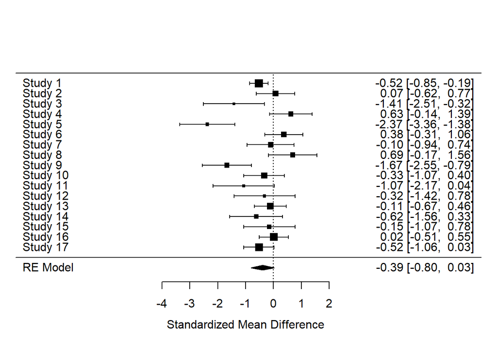

```r
# make a default forest plot
forest(mod_multilevel_SMD)
```

### Figure S2

Forest plot showing the results of 17 effect sizes quantifying the effect of SSRI exposure on animal sensory processing (data from Ramsteijn et al. (2020)).

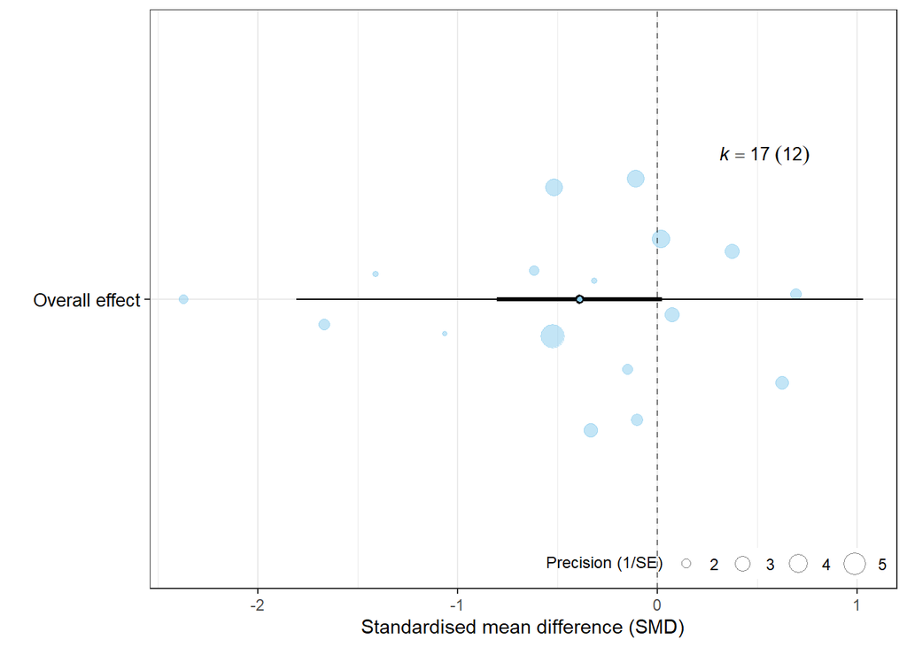

```r
# make a orchard plot
orchard_plot(mod_multilevel_SMD, mod = "1", xlab = "Standardised mean difference (SMD)",
    group = "Study_ID", data = dat_sensory2, k = TRUE, g = TRUE, transfm = "none",
    angle = 0) + scale_x_discrete(labels = c("Overall effect"))
```

### Figure S3

Orchard plot (forest-like plot) showing the results of 17 effect sizes quantifying the effect of SSRI exposure on animal sensory processing (data from Ramsteijn et al. (2020)). You can use help(orchard_plot) to look at the corresponding arguments and add more code to make it more elegant.

**The outputs of the fitted multilevel model look:**

```r
summary(mod_multilevel_SMD)
```

```
##
## Multivariate Meta-Analysis Model (k = 17; method: REML)
##
##   logLik  Deviance       AIC       BIC      AICc
## -18.7458   37.4915   43.4915   45.8093   45.4915
##
## Variance Components:
##
##             estim    sqrt  nlvls  fixed    factor
## sigma^2.1  0.1455  0.3815     12     no  Study_ID
## sigma^2.2  0.2636  0.5134     17     no    Obs_ID
##
## Test for Heterogeneity:
## Q(df = 16) = 52.2611, p-val < .0001
##
## Model Results:
##
## estimate      se     tval  df    pval    ci.lb   ci.ub
##  -0.3887  0.1953  -1.9904  16  0.0639  -0.8026  0.0253  .
##
## ---
## Signif. codes:  0 '***' 0.001 '**' 0.01 '*' 0.05 '.' 0.1 ' ' 1
```

Next, let’s go through the model outputs one by one.

**Under Multivariate Meta-Analysis Model:**

**Under Variance Components:**

This section shows the variance estimated for each level of the fitted 3-level model. The first one, `sigma^2.1`, represents the level 3 between-study variance, $\sigma_{between}^2$. Conceptually, this is equivalent to between-study heterogeneity variance $\tau^2$ in a random-effects model - Equation 1 (but the values of $\sigma_{between}^2$ and $\tau^2$ are not the same; see next section: Comparing the multilevel and random-effects models). The second variance component, `sigma^2.2`, represents the level 2 within-study variance, $\sigma_{within}^2$. The heading code>estim shows the estimates of variance components in levels 3 and 2 ($\sigma_{between}^2$ and $\sigma_{within}^2$). The heading code>sqrt shows the standard deviation of variance components - square root of $\sigma^2$. The column of `nlvls` shows how many levels each random effect has. `factor` is the name of the clustering variables we used in the `random` argument to specify corresponding random effects.

**Under Test for Heterogeneity:**

This section shows results of Cochran’s Q-test, which is used to test the null hypothesis that all animal studies have a same/equal effect. `p-val` < 0.05 means that effect sizes derived from the animal studies are heterogeneous. In other words, substantial heterogeneity exists in this animal dataset.

**Under Model Results:**

`estimate` is the estimate of the overall/pooled effect (i.e., grand mean or meta-analytic mean; $\beta_{0}$ in Equation 2). `se` is the standard error of the estimate: as in our example, it is (SE[$\beta_{0}$]. `tval` is the value of test statistic (in our case: t-value). `ci.lb` and `ci.Ub` are lower and upper boundary of confidence intervals.

## 2.4 Handle non-independence to avoid the distortion of significance test and spurious conclusions

As mentioned in the main text, the traditional statistical models used in animal meta-analyses often fail to handle statistical non-dependence, inflating type I error, distorting significance test and leading to spurious conclusions. This worked example exactly shows this point. Same to a random-effects meta-analysis, the first aim of a multilevel meta-analysis is often to estimate the overall effect across all animal studies (meta-analytic mean; $\beta_{0}$ in Equation 2). Under `Model Results`, we can see what we need for this aim: the magnitude of the overall effect ($\beta_{0}$), standard error (SE[$\beta_{0}$]), corresponding two-tailed p-value, and 95% confidence intervals (CIs). The multilevel showed that animals exposed to SSRIs did not have a significantly less efficient sensory processing than those exposed to vehicle ($\beta_{0}$ = -0.389, 95% CIs = [-0.803 to 0.025], p-value = 0.064).

**Conflicting results between the multilevel model and random-effect model**

When comparing the results of our 3-level model with Ramsteijn et al. (2020)’s original results, we found that the conclusions of our 3-level model conflict with those reached by Ramsteijn et al. (2020) (who used the random-effects model). Ramsteijn et al. (2020)’s analysis (page 62) indicates that SSRI exposure has a statistically significant decreasing effect on sensory processing in animals (our re-analysis of using the random-effects model also suggested this point). **However**, the multilevel model suggests that the SSRI-effect is non-significant (Table S3).

### Table S3

Results of the random-effects and 3-level meta-analytic models.

```r
t3 <- data.frame(`Model type` = c("random-effects model", "Multi-level model"), `Overall effect` = c(round(mod_random_SMD2$b[1],
    2), round(mod_multilevel_SMD$b[1], 2)), `Standard error` = c(round(mod_random_SMD2$se,
    2), round(mod_multilevel_SMD$se, 2)), `p-value` = c(round(mod_random_SMD2$pval,
    3), round(mod_multilevel_SMD$pval, 3)), `Lower CI` = c(round(mod_random_SMD2$ci.lb,
    2), round(mod_multilevel_SMD$ci.lb, 2)), `Upper CI` = c(round(mod_random_SMD2$ci.ub,
    2), round(mod_multilevel_SMD$ci.ub, 2)), `Between-study variance` = c(round(mod_random_SMD2$tau2,
    2), round(mod_multilevel_SMD$sigma2[1], 2)), `Within-study variance` = c(0, round(mod_multilevel_SMD$sigma2[2],
    2)), `Between-study I2` = c(round(mod_random_SMD2$I2, 2), round(i2_ml(mod_multilevel_SMD)[[2]] *
    100, 2)), `Within-study I2` = c(0, round(i2_ml(mod_multilevel_SMD)[[3]] * 100,
    2)))

names(t3) <- c("Model type", "Overall effect", "Standard error", "p-value", "Lower CI",
    "Upper CI", "Between-study variance", "Within-study variance", "Between-study I2",
    "Within-study I2")

kable(t(t3))
```

| Model type | random-effects model | Multi-level model |
| --- | --- | --- |
| Overall effect | -0.38 | -0.39 |
| Standard error | 0.16 | 0.20 |
| p-value | 0.034 | 0.064 |
| Lower CI | -0.72 | -0.80 |
| Upper CI | -0.03 | 0.03 |
| Between-study variance | 0.29 | 0.15 |
| Within-study variance | 0.00 | 0.26 |
| Between-study I2 | 69.38 | 2717.12 |
| Within-study I2 | 0.00 | 4920.67 |

# 3. Partition heterogeneity among effect size using the multilevel model

## 3.1 Calculate multilevel version of I2 statistic and variance components

As with the traditional meta-analytic models (i.e., fixed- and random-effects models), the multilevel model also can measure the degree of inconsistency among effect sizes (i.e., the amount of heterogeneity). The hierarchical nature of this dataset means that this animal meta-analysis can be benefited from decomposing heterogeneity across levels, e.g., within- and between-study heterogeneity (more complex heterogeneity source: species-specific heterogeneity; see our second worked example). However, the random-effects model can only quantify between-study heterogeneity, which makes within-study heterogeneity mistakenly perceived as between-study heterogeneity (i.e., confounding source of heterogeneity). Below, we use this worked example to show how to partition multiple sources of heterogeneity using the multilevel version of I2 statistic and variance components, such that we can avoid confounded heterogeneity.

You can use the following formulas to calculate the multilevel version of I2 statistic (Equations 4 to 6 in the main text):
$$I^2_{between}=\frac{\sigma_{between}^2} {Var[ES_{i}]}=\frac{\sigma_{between}^2} {\sigma_{total}^2+\sigma_{sampling}^2}, (4)$$

$\sigma_{between}^2$ and $\sigma_{within}^2$ are the variance components corresponding to between- and within-study level random-effects in the multilevel model (specified by the syntax `random = list(~ 1 | Study_ID, ~ 1 | Obs_ID)` in `rma.mv()`). The value of each level of $\sigma^2$ can be found at the **Under Variance Components**. $\sigma_{total}^2$ is the total variance, whose value equals to the sum of $\sigma_{between}^2$ and $\sigma_{within}^2$. $\sigma_{sampling}^2$ is a “typical” sampling-error variance, which can be calculated by:
$$\sigma_{sampling}^2=\frac{(k-1)\sum_{i=1}^{k} 1/\nu_{i}} {(\sum_{i=1}^{k} 1/\nu_{i})^2-\sum_{i=1}^{k} 1/\nu_{i}^2}, (7)$$

In reality, your do not need to calculate multilevel versions of I2 statistic manually. `i2_ml()` function in `orchaRd` package is very convenient and user-friendly to decompose I2 statistic across levels: . You can calculate multilevel version of I2 statistic with:

```
i2_ml(mod_multilevel_SMD)
```

Then $I^2$ statistics corresponding to each level (including $I^2_{total}$) are provided:

```r
i2_ml(mod_multilevel_SMD)
```

```
##    I2_Total I2_Study_ID   I2_Obs_ID
##    76.37792    27.17122    49.20670
```

## 3.3 Compute prediction intervals

We recommend researchers use another statistic index to quantify heterogeneity - prediction interval (PI), which is defined as the estimate of an interval (a plausible value range) where the future measurements (i.e., new effect sizes) would fall when no sampling errors exist. This can be calculated by (see Equation 8 in the main text for notions):
$$\text{95%PI} = \beta_{0} \pm t_{0.975} \sqrt{\sigma^2_{total}+ \text{SE}[\beta_{0}^2]}, (8)$$
All the required elements can be found at the outputs of the `rma.mv()` (see **Interpretation of the results of a multilevel meta-analytic model**). You can also use an existing function - `predict()` to obtain 95% PI for the overall effect:

```
predict(mod_multilevel_SMD)
```

The argument `mod = “Int”` means that the 95% PIs of the intercept ($\beta_{0}$; overall effect) are specified.

The corresponding output look:

```r
PI_int_SMD <- predict(mod_multilevel_SMD)
PI_int_SMD
```

```
##
##     pred     se   ci.lb  ci.ub   pi.lb  pi.ub
##  -0.3887 0.1953 -0.8026 0.0253 -1.8064 1.0290
```

We can see that 95% PIs of the overall effect of SSRI are [-1.81,1.03], which means 95% of new trials regarding the perinatal SSRI exposure will have an effect size (i.e., SMD) in the range of [-1.81,1.03] over different experimental contexts (across different types of SSRI, animal species, sex and ages).

# 4. Fit multilevel meta-regressions to explain heterogeneity and estimate moderator effects

## 4.1 Concepts and rationale

A large $I^2_{total}$ = 76.38% in this dataset indicates that we need to explain (at least part of) this heterogeneity using variables extracted from primary studies as moderators (also known as predictors). In other words, we need to examine how different study-level characteristics (variables/factors) modulate the magnitude of the effect of SSRI exposure. Ramsteijn et al. (2020) used the subgroup analysis to explain the heterogeneity in the effect sizes. Here, we recommend using a multilevel meta-regression model to explain the heterogeneity and examine the moderator effects:
$$ES_{[i]} = \beta_{0}' + \beta_{1}x_{between[j]} + \mu_{between[j]} + \mu_{within[i]} + e_{[i]}, (8)\\ \mu_{between[j]} \sim N(0,\sigma_{between}^2)\\ \mu_{within[i]} \sim N(0,\sigma_{within}^2)\\ e_{[i]} \sim N(0,\nu_{[i]})$$
As we illustrate in the main text, a subgroup analysis is equivalent to a meta-regression model if using a dummy-coding strategy to deal with categorical predictors (note that in the context of meta-analysis, we usually call a predictor as a moderator). In the main text, we use an example to show how to dummy-code categorical moderators for a multilevel meta-regression. The rationale of dummy-coding strategy is to (1) create dummy-coded variables for a categorical moderator to represent different levels, (2) left one of the dummy variables out of the regression model and set its level as the “reference” level (see details in the main text). Other than creating the dummy-coded variables by hand, we prefer to let `R` dummy-code categorical moderators automatically.

## 4.2 Construct a multilevel meta-regression model

A multilevel regression model (e.g., Equation 8) can be fitted using `rma.mv()` function. The `mods` argument in `rma.mv()` is used to specify the categorical moderators (also the continuous moderators). The syntax for `mods` is as follows: starting with a tilde `~` (a general requirement of a formula in `R`), followed by the name of the moderator (e.g., `mods = ~ moderator1`).

In this worked example, Ramsteijn et al. (2020) examined whether the effects of SSRI exposure differ depending on sex (male, female, or both). This categorical moderator is labelled as ‘Sex’ column in this dataset. A 3-level meta-regression model with sex a moderator can be fitted using the follow code:

```
rma.mv(yi = SMD,
       V = SMDV,
       random = list(~1 | Study_ID, ~1 | Obs_ID),
       mods = ~ Sex, # the name of the tested moderator; this can be replaced by other moderators of interests;
       test = "t",
       method = "REML",
       data = dat_sensory2)
```

See **Interpretations of a multilevel meta-regression model** for a comprehensive interpretation of the outputs for the above fitted meta-regression model.

## 4.3 Interpretations of a multilevel meta-regression model

```r
### multilevel meta-regression model using sex as a moderator
mod_multilevel_reg_sex_SMD <- metafor::rma.mv(yi = SMD, V = SMDV, random = list(~1 |
    Study_ID, ~1 | Obs_ID), mods = ~Sex, test = "t", method = "REML", data = dat_sensory2)
```

We can use `orchard_plot()` to make a orchard plot to visualise the results of a multilevel meta-regression model. Figure S4 shows that neither *Male*, *Female*, nor *Both* have a statistically significant effect.

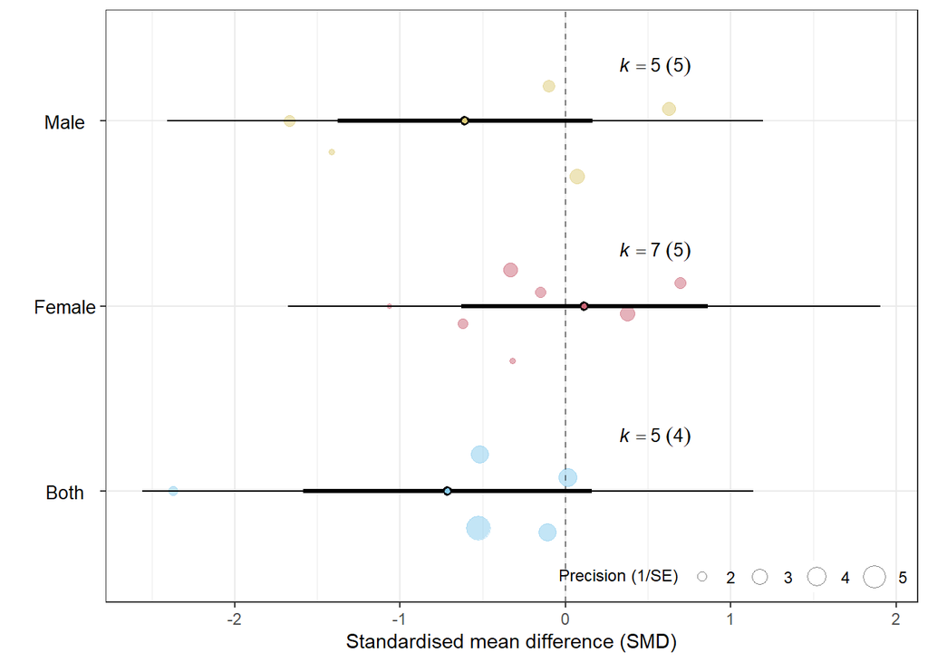

```r
# make a orchard plot
orchard_plot(mod_multilevel_reg_sex_SMD, mod = "Sex", xlab = "Standardised mean difference (SMD)",
    group = "Study_ID", data = dat_sensory2, k = TRUE, g = TRUE, transfm = "none",
    angle = 0)
```

### Figure S4

Orchard plot (forest-like plot) showing the mediated effect of sex on the effect sizes quantifying the effect of SSRI exposure on animal sensory processing (data from Ramsteijn et al. (2020)). You can use help(orchard_plot) to look at the corresponding arguments and add more code to make it more elegant.

**Using `rma.mv()` to fit a multilevel meta-regression model will yield the following outputs:**

```r
summary(mod_multilevel_reg_sex_SMD)
```

```
##
## Multivariate Meta-Analysis Model (k = 17; method: REML)
##
##   logLik  Deviance       AIC       BIC      AICc
## -15.9626   31.9253   41.9253   45.1206   49.4253
##
## Variance Components:
##
##             estim    sqrt  nlvls  fixed    factor
## sigma^2.1  0.5488  0.7408     12     no  Study_ID
## sigma^2.2  0.0275  0.1657     17     no    Obs_ID
##
## Test for Residual Heterogeneity:
## QE(df = 14) = 49.0716, p-val < .0001
##
## Test of Moderators (coefficients 2:3):
## F(df1 = 2, df2 = 14) = 2.2580, p-val = 0.1413
##
## Model Results:
##
##            estimate      se     tval  df    pval    ci.lb   ci.ub
## intrcpt     -0.7107  0.4069  -1.7465  14  0.1026  -1.5835  0.1621
## Sexfemale    0.8267  0.5356   1.5435  14  0.1450  -0.3220  1.9753
## Sexmale      0.1044  0.5424   0.1924  14  0.8502  -1.0591  1.2678
##
## ---
## Signif. codes:  0 '***' 0.001 '**' 0.01 '*' 0.05 '.' 0.1 ' ' 1
```

Next, let’s go through the outputs one by one.

**Multivariate Meta-Analysis Model**

The interpretations of the results under **Multivariate Meta-Analysis Model** are same with those in the section of **Interpretations of a multilevel meta-analytic model**.

**Variance Components**

The interpretations of the results under **Variance Components** are same with those in the section of **Interpretations of a multilevel meta-analytic model**.

**Test for Residual Heterogeneity**

Results under **Test for Residual Heterogeneity** are similar to **Test for Heterogeneity** in the section of **Interpretations of a multilevel meta-analytic model**. But the two are not exactly the same. `QE` is the test statistic used to test whether the amount of ‘residual heterogeneity’ among the effect sizes is substantial. ‘residual heterogeneity’ means that the amount of heterogeneity that is not explained by the moderator of sex added in the meta-regression model. From the results, we can see that the inclusion of sex as a moderator only can reduce a little of heterogeneity (`Q` is reduced from 52.2611 to 49.0716). `p-val` < 0.0001 indicates that residual heterogeneity still remains statistically meaningful.

**Test of Moderators (coefficients 2:3)**

**Model Results**

By using a different syntax strategy, we can directly obtain the pooled $SMD$ for each subgroup. To achieve this, we need to add `-1` at the end of `mods = ~ Sex` (i.e., `mods = ~ Sex -1`). `-1` means that the intercept ($\beta_{0}$) will be removed the meta-regression model. The whole code is:

```
rma.mv(yi = SMD,
       V = SMDV,
       random = list(~1 | Study_ID, ~1 | Obs_ID),
       mods = ~ Sex -1, # remove the intercept from the meta-regression;
       test = "t",
       method = "REML",
       data = dat_sensory2)
```

**The results of meta-regression corresponding to the strategy of `-1` (removing the intercept):**

```r
### multilevel meta-regression model using sex as a moderator
mod_multilevel_reg_sex_SMD2 <- rma.mv(yi = SMD, V = SMDV, random = list(~1 | Study_ID,
    ~1 | Obs_ID), mods = ~Sex - 1, test = "t", method = "REML", data = dat_sensory2)


summary(mod_multilevel_reg_sex_SMD2)
```

```
##
## Multivariate Meta-Analysis Model (k = 17; method: REML)
##
##   logLik  Deviance       AIC       BIC      AICc
## -15.9626   31.9253   41.9253   45.1206   49.4253
##
## Variance Components:
##
##             estim    sqrt  nlvls  fixed    factor
## sigma^2.1  0.5488  0.7408     12     no  Study_ID
## sigma^2.2  0.0275  0.1657     17     no    Obs_ID
##
## Test for Residual Heterogeneity:
## QE(df = 14) = 49.0716, p-val < .0001
##
## Test of Moderators (coefficients 1:3):
## F(df1 = 3, df2 = 14) = 2.4084, p-val = 0.1106
##
## Model Results:
##
##            estimate      se     tval  df    pval    ci.lb   ci.ub
## Sexboth     -0.7107  0.4069  -1.7465  14  0.1026  -1.5835  0.1621
## Sexfemale    0.1160  0.3482   0.3330  14  0.7441  -0.6309  0.8628
## Sexmale     -0.6063  0.3587  -1.6904  14  0.1131  -1.3757  0.1630
##
## ---
## Signif. codes:  0 '***' 0.001 '**' 0.01 '*' 0.05 '.' 0.1 ' ' 1
```

## 4.4 Calculate the goodness-of-fit index

For a multilevel meta-regression model, the goodness-of-fit index $R^2$ is also applicable to quantify the percentage of variance explained by the included moderator variables (Aloe et al., 2010). Nakagawa and Schielzeth, 2013 propose to use a general from of $R^2$ - marginal $R^2$, which can be calculated by:

$$R^2_{marginal}=\frac{\sigma_{fixed}^2} {\sigma_{total}^2}=\frac{\sigma_{fixed}^2} {\sigma_{fixed}^2+\sigma_{b}^2+\sigma_{w}^2}, (10)$$
You can easily calculate $R^2_{marginal}$ via the function `r2_ml()` in our R package `orchaRd`:

```
r2_ml(mod_multilevel_reg_sex_SMD)
```

```r
r2_ml(mod_multilevel_reg_sex_SMD)
```

```
##    R2_marginal R2_conditional
##      0.2130917      0.9624983
```

The first column of the output (`R2_marginal`) shows that animal sex can explain 21.3% variation.

# 5. Test publication bias

As mentioned in the main text, the common methods to test publication bias will be invalid if effect sizes are statistically dependent. Therefore, funnel plots, Egger’s regression and trim-and-fill tests are not suitable to test publication bias. In this section, we showcase how to properly test two forms of publication bias in the framework of multilevel meta-regression: small-study effect and decline effect (implementation of section 8.2).

## 5.1 Construct an extended Egger’s regression to test the small-study effect

The first form publication bias is the small-study effect, which occurs when small studies (small sample size) tend to report large effect sizes. As outlined in the main text, an extended Egger’s regression is equivalent to a multilevel meta-regression with sampling error ($se_{[i]}=\sqrt{\nu_{[i]}}$) as a continuous moderator variable. Accordingly, it can be fitting via specifying `mods = ~ SMDSE`:

```
rma.mv(yi = SMD,
       V = SMDV,
       random = list(~1 | Study_ID, ~1 | Obs_ID),
       mods = ~ SMDSE, # sampling error (squart root of sampling variance SMDV);
       test = "t",
       method = "REML",
       data = dat_sensory2)
```

See **Interpretations of the small-study effect test** for how to interpret extended Egger’s regression’s results.

## 5.2 Interpretations of the small-study effect test

**The outputs of a typical extended Egger’s regression model looks:**

```r
### calculate sampling error for SMD
dat_sensory2$SMDSE <- sqrt(dat_sensory2$SMDV)

### run an extended Egger's regression model
pb_small.study.effect_SMD <- metafor::rma.mv(yi = SMD, V = SMDV, random = list(~1 |
    Study_ID, ~1 | Obs_ID), mods = ~SMDSE, test = "t", method = "REML", data = dat_sensory2)

summary(pb_small.study.effect_SMD)
```

```
##
## Multivariate Meta-Analysis Model (k = 17; method: REML)
##
##   logLik  Deviance       AIC       BIC      AICc
## -16.8403   33.6805   41.6805   44.5127   45.6805
##
## Variance Components:
##
##             estim    sqrt  nlvls  fixed    factor
## sigma^2.1  0.2730  0.5225     12     no  Study_ID
## sigma^2.2  0.1505  0.3879     17     no    Obs_ID
##
## Test for Residual Heterogeneity:
## QE(df = 15) = 51.2431, p-val < .0001
##
## Test of Moderators (coefficient 2):
## F(df1 = 1, df2 = 15) = 2.5477, p-val = 0.1313
##
## Model Results:
##
##          estimate      se     tval  df    pval    ci.lb   ci.ub
## intrcpt    0.7127  0.7201   0.9897  15  0.3380  -0.8222  2.2476
## SMDSE     -2.8426  1.7809  -1.5962  15  0.1313  -6.6385  0.9533
##
## ---
## Signif. codes:  0 '***' 0.001 '**' 0.01 '*' 0.05 '.' 0.1 ' ' 1
```

Under **Model Results**, we can see that the regression slope of the extended Egger’s regression is `sqrt(SMDSE)` = -2.8426, which is not statistically different from zero (`t_value` = -1.5962 and `p-val` = 0.1313). This means smaller studies (larger sampling error [$se_{[i]}=\sqrt{\nu_{[i]}}$]) does not have larger effect effect sizes (Figure S5): no small-study effect exists in this dataset. The non-significant slope `sqrt(SMDSE)` = -2.8426 also indicates that data is symmetrically distributed on the funnel plot (Figure S6).

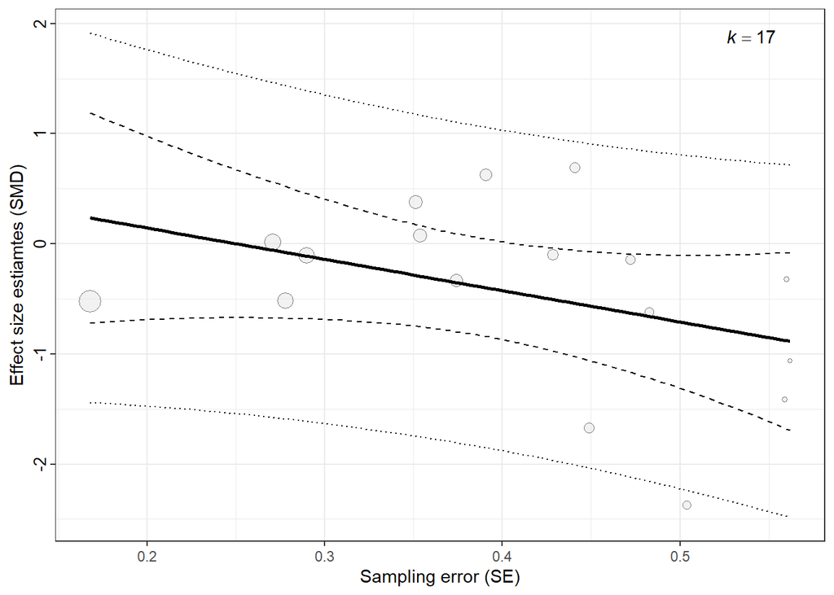

```r
# visualize the extended Egger's regression model
pb_small.study.effect_SMD_plot <- bubble_plot(pb_small.study.effect_SMD, mod = "SMDSE",
    xlab = "Sampling error (SE)", ylab = "Effect size estiamtes (SMD)", group = "Study_ID",
    data = dat_sensory2, legend.pos = "none")

pb_small.study.effect_SMD_plot
```

### Figure S5

A bubble plot showing the relationship between effect size estimates (SMD) and their sampling error (SE) can be used to detect the small-study effect (funnel plot asymmetry). This bubble plot can be made using `bubble_plot()` function in `orchaRd` package.

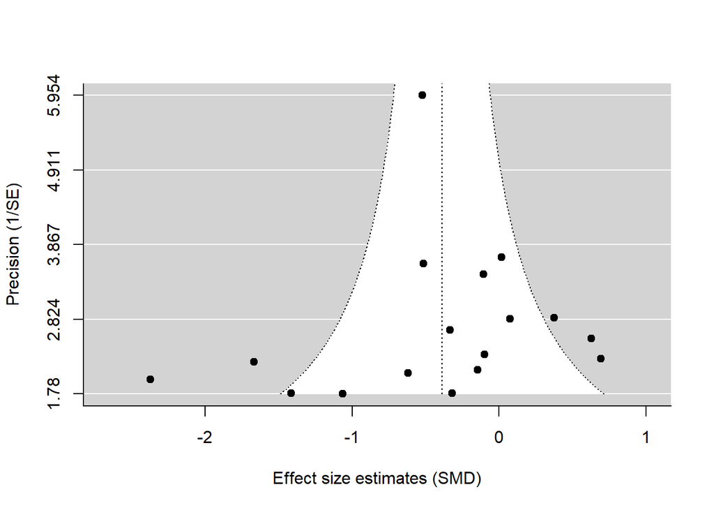

```r
# make a funnel plot
funnel(mod_multilevel_SMD, yaxis = "seinv", ylab = "Precision (1/SE)", xlab = "Effect size estimates (SMD)")
```

### Figure S6

Visual inspection of the funnel plot to identify the small-study effect.

The interpretations of other outputs of the extended Egger’s regression model are same to those in a multilevel meta-regression, including (1) **Multivariate Meta-Analysis Model**; (2) **Variance Components**; (3) **Test for Residual Heterogeneity**; (4) **Test of Moderators**; (5) **Model Results**. You can refer to **Interpretations of a multilevel meta-analytic model** in Step 3 for thorough interpretations.

Of note, when using SMD as a effect size metric, using Egger’s test to identify small-study effect may produce false-positive results. If you have a look at the formula used to compute SMD’s SE (which can be found elsewhere), you may realise that SMD is artifactually correlated with its SE , meaning that SMD’s SE is dependent on SMD. Shinichi et al (2022) propose to use an adapted SE when using Egger’s regression to test the small-study effect on SMD. The adapted SE is based on the effective sample size:
$$\sqrt{\frac {1} { \tilde{N} }} =
\sqrt{\frac {1} { N_\text{T}} + \frac{1}{N_\text{C}}},$$
Therefore, it is necessary to conduct a sensitivity analysis using this adapted SE to check the robustness of small-study test. This can be easily done by replacing SE with the adapted SE in the extended Egger’s regression model. Under **Model Results** (see below), we can see that the slope of the adapted SE `sqrt(SMDSE_C)` = -1.2521 still shows non-significant (`t_value` = -0.6042 and `p-val` = 0.5548), which indicates the the robustness of the small-study test.

```r
# calculate modified SE
dat_sensory2$SMDSE_c <- with(dat_sensory2, sqrt((SSRI_Nadj + Vehicle_Nadj)/(SSRI_Nadj *
    Vehicle_Nadj)))

### re-run the extended Egger's regression model with adapted SE to obtain
### robust results
pb_small.study.effect_SMD2 <- metafor::rma.mv(yi = SMD, V = SMDV, random = list(~1 |
    Study_ID, ~1 | Obs_ID), mods = ~SMDSE_c, test = "t", method = "REML", data = dat_sensory2)

summary(pb_small.study.effect_SMD2)
```

```
##
## Multivariate Meta-Analysis Model (k = 17; method: REML)
##
##   logLik  Deviance       AIC       BIC      AICc
## -17.8446   35.6892   43.6892   46.5214   47.6892
##
## Variance Components:
##
##             estim    sqrt  nlvls  fixed    factor
## sigma^2.1  0.2387  0.4885     12     no  Study_ID
## sigma^2.2  0.2293  0.4789     17     no    Obs_ID
##
## Test for Residual Heterogeneity:
## QE(df = 15) = 52.2585, p-val < .0001
##
## Test of Moderators (coefficient 2):
## F(df1 = 1, df2 = 15) = 0.3650, p-val = 0.5548
##
## Model Results:
##
##          estimate      se     tval  df    pval    ci.lb   ci.ub
## intrcpt    0.0728  0.7986   0.0912  15  0.9285  -1.6293  1.7750
## SMDSE_c   -1.2521  2.0724  -0.6042  15  0.5548  -5.6693  3.1651
##
## ---
## Signif. codes:  0 '***' 0.001 '**' 0.01 '*' 0.05 '.' 0.1 ' ' 1
```

## 5.3 Construct a multilevel regression model to test the time-lag bias

Time-lag bias occurs when statistically significant (aks positive results) tend to publish earlier than those with statistically non-significant findings (aks negative results), leading to a decline in reported effect sizes over time (i.e., decline effect).

Time-lag bias has very important implication to a field, for example, the instability of the cumulative evidence of a given field poses a threat to policy-marking and (pre)clinical decisions. However, this form of publication bias has been rarely tested in the practice of animal meta-analyses. The test of time-lag bias is very straightforward. You only need to add the publication year of the effect size as a continuous moderator variable in a multilevel regression model (equivalent to replacing sampling error ($se_{[i]}=\sqrt{\nu_{[i]}}$) by publication year):

```
rma.mv(yi = SMD,
       V = SMDV,
       random = list(~1 | Study_ID, ~1 | Obs_ID),
       mods = ~ pub_year, # publication year of the effect sizes (in this case, SMD);
       test = "t",
       method = "REML",
       data = dat_sensory2)
```

See **Interpretations of the time-lag bias test** for how to interpret time-lag bias test’s results.

## 5.4 Interpretations of the time-lag bias test

**The outputs of a typical time-lag bias test looks:**

```r
### create publication year variable
dat_sensory2$pub_year <- dat_sensory2$Year

### run multilevel regression model to test time-lag bias
pb_time.lag.bias_SMD <- metafor::rma.mv(yi = SMD, V = SMDV, random = list(~1 | Study_ID,
    ~1 | Obs_ID), mods = ~pub_year, test = "t", method = "REML", data = dat_sensory2)

summary(pb_time.lag.bias_SMD)
```

```
##
## Multivariate Meta-Analysis Model (k = 17; method: REML)
##
##   logLik  Deviance       AIC       BIC      AICc
## -17.9355   35.8711   43.8711   46.7033   47.8711
##
## Variance Components:
##
##             estim    sqrt  nlvls  fixed    factor
## sigma^2.1  0.2666  0.5163     12     no  Study_ID
## sigma^2.2  0.2168  0.4656     17     no    Obs_ID
##
## Test for Residual Heterogeneity:
## QE(df = 15) = 51.9927, p-val < .0001
##
## Test of Moderators (coefficient 2):
## F(df1 = 1, df2 = 15) = 0.0002, p-val = 0.9898
##
## Model Results:
##
##           estimate        se     tval  df    pval      ci.lb     ci.ub
## intrcpt    -1.9368  119.1649  -0.0163  15  0.9872  -255.9309  252.0573
## pub_year    0.0008    0.0592   0.0130  15  0.9898    -0.1254    0.1269
##
## ---
## Signif. codes:  0 '***' 0.001 '**' 0.01 '*' 0.05 '.' 0.1 ' ' 1
```

Similar to decline effect test, under **Model Results**, we can see that the regression slope is `pub_year` = 0.0008, which is very small and not statistically different from zero (`t_value` = 0.0130 and `p-val` = 0.9898). This means studies with statistically significant findings do not tend to publish earlier than that with negative results: no time-lag bias exists in this dataset. Figure S7 clearly shows that the estimates of SMD remains consistent across different publication year.

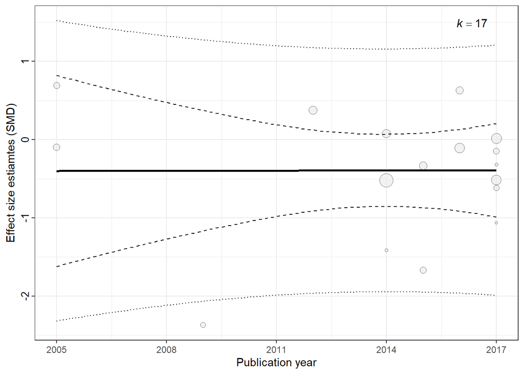

```r
# visualize the time-lag bias test
pb_time.lag.bias_SMD_plot <- bubble_plot(pb_time.lag.bias_SMD, mod = "pub_year",
    xlab = "Publication year", ylab = "Effect size estiamtes (SMD)", group = "Study_ID",
    data = dat_sensory2, legend.pos = "none") + scale_x_continuous(limits = c(2005,
    2017), breaks = seq(2005, 2017, 3))

pb_time.lag.bias_SMD_plot
```

### Figure S7

A bubble plot showing the relationship between effect size estimates (SMD) and their publication year can be used to detect the time-lag bias (aka decline effect). This bubble plot can be made using `bubble_plot()` function in `orchaRd` package.

The interpretations of other outputs of the extended Egger’s regression model are same to those in a multilevel meta-regression, including (1) **Multivariate Meta-Analysis Model**; (2) **Variance Components**; (3) **Test for Residual Heterogeneity**; (4) **Test of Moderators**; (5) **Model Results**. You can refer to **Interpretations of a multilevel meta-analytic model** in Step 3 for thorough interpretations.

# 6. Select an appropriate random-effect structure

In this section, we use a more complex animal dataset to show how to select an appropriate random-effect structure, and therefore, to account for various types of non-independence and heterogeneity at different levels. This dataset comes from Lagisz et al., 2020, which examined cognition bias across 22 animal species using 71 studies with 459 effect sizes.

## 6.1 Concepts and rationale

When specifying a multilevel meta-analytic model, a practical question to consider is which study-level variables to give random effects. You may wonder what is a ‘random effect?’ There are many formal definitions (Andrew Gelman has a nice blog on it: https://statmodeling.stat.columbia.edu/2005/01/25/why_i_dont_use/). Here, we give a non-statistical definition in the context of meta-analysis: a study-level variable being random-effect means that it varies across different intervention types, doses, and species. When a study-level variable in a meta-analytic model is modeled as being a random-effect, we believe that it has a random effect on the overall mean and contributes noise (variation) to the overall mean. For example, including animal strains/species as a random-effect will allow us to estimate how much variance exists among strains/species. In contrast, when treating strains/species as a fixed-effect, we believe that strains/species levels are identical across different studies and have a systematic effect on the mean (e.g., ask question like, do one species response more effectively to a intervention than others?). A general guideline choosing random-effect factor is that it should contain at least five levels, so that we can properly report variance (Bolker et al., 2009).

## 6.2 Choose a random-effect structure based on AIC

Theoretically, any cluster/group variable having more than five level can be a random-effects candidate (e.g., animal species). Should we include every cluster/group variable (> five levels) as a random-effects in the multilevel model? The answer is NO! For a random-effect candidate, you first need to think about whether it is of neurobiologically interesting and true sources of heterogeneity based on your expertise. Then you need to investigate whether this random-effect candidate improve the quality of the multilevel model. In this respect, you need to resort to information-theoretic approaches alongside likelihood methods (likelihood ratio tests). Here, we use Lagisz et al., 2020’s dataset to show how to decide the best random-effects structure from the view of Akaike Information Criterion (AIC) criteria. This can be easily done by (1) specifying the argument `random` in `rma.mv` function with different random-effects structures; (2) using `anova.rma` to provide a full versus reduced model comparison in terms of model fit statistics and a likelihood ratio test (log-likelihood, deviance, AIC, BIC, and AICc).

Lagisz et al., 2020’s dataset has three random-effects candidates:

Effect size identity (*EffectID*) - unique ID for each pairwise comparison used to calculate effect sizes; modelling it as a random-effect means to allow true effect sizes to vary within studies, such that the model can estimate with-study (effect size) level variance ($\sigma_{within}^2$) and partition with-study (effect size) level heterogeneity ($I^2_{within}$);

Study identity (*ArticleID*) - unique ID for each extracted original experimental paper; modelling it as a random-effect means to allow true effect sizes to vary across studies, such that the model can estimate between-study level variance ($\sigma_{between}^2$) and partition between-study level heterogeneity ($I^2_{between}$);

Species identity (*Species_Latin*) - Latin name of an animal species used in the experiment; modelling it as a random-effect means to allow true effect sizes to vary across species, such that the model can estimate species level variance ($\sigma_{species}^2$) and partition species level heterogeneity ($I^2_{species}$).

### Table S4

Load data of Lagisz et al., 2020.

```r
# load data
dat_cognition <- read.csv("./data/Lagisz_2020.csv")

t4 <- dat_cognition %>%
    DT::datatable(rownames = FALSE, width = "100%", options = list(dom = "t", scrollY = "700px",
        pageLength = 20))  #, pageLength = 2
t4
```

| EffectID | ArticleID | ExperimentID | GroupID | Authors | Journal | JournalType | Year | ArticleTitle | Species | ScientificName | Taxa | Breed | Captive_Wild.caught | Age | WithinBetween | CrossoverDesign | StudyDesign | Blind | Automated | FoodDeprived | TaskType | CueTypeDetails | CueTypeCat | ResponseTypeDetails | OutcomeCorrectPosCue | OutcomeIncorrectPosCue | OutcomeCorrectNegCue | OutcomeIncorrectNegCue | ReinforcementCat | … |
| --- | --- | --- | --- | --- | --- | --- | --- | --- | --- | --- | --- | --- | --- | --- | --- | --- | --- | --- | --- | --- | --- | --- | --- | --- | --- | --- | --- | --- | --- | --- |
| ES_19 | Bateson2007 | exp005 | grp002 | Bateson, M., Matheson, S. M. | Animal Welfare | Peer-reviewed | 2007 | Performance on a categorisation task suggests that removal of environmental enrichment induces 'pessimism' in captive European starlings (Sturnus vulgaris) | european starling | Sturnus_vulgaris | bird | n/a | wild-caught | adult | within | yes | within (crossover) | no | no | yes | go/no-go | colour | visual | lid-flip | palatable mealworm | no palatable mealworm | no unpalatable mealworm (0.2 ml 2% quinine) | unpalatable mealworm (0.2 ml 2% quinine) | R-P | … |
| ES_20 | Bateson2007 | exp005 | grp002 | Bateson, M., Matheson, S. M. | Animal Welfare | Peer-reviewed | 2007 | Performance on a categorisation task suggests that removal of environmental enrichment induces 'pessimism' in captive European starlings (Sturnus vulgaris) | european starling | Sturnus_vulgaris | bird | n/a | wild-caught | adult | within | yes | within (crossover) | no | no | yes | go/no-go | colour | visual | lid-flip | palatable mealworm | no palatable mealworm | no unpalatable mealworm (0.2 ml 2% quinine) | unpalatable mealworm (0.2 ml 2% quinine) | R-P | … |
| ES_21 | Bateson2007 | exp005 | grp002 | Bateson, M., Matheson, S. M. | Animal Welfare | Peer-reviewed | 2007 | Performance on a categorisation task suggests that removal of environmental enrichment induces 'pessimism' in captive European starlings (Sturnus vulgaris) | european starling | Sturnus_vulgaris | bird | n/a | wild-caught | adult | within | yes | within (crossover) | no | no | yes | go/no-go | colour | visual | lid-flip | palatable mealworm | no palatable mealworm | no unpalatable mealworm (0.2 ml 2% quinine) | unpalatable mealworm (0.2 ml 2% quinine) | R-P | … |
| ES_22 | Bateson2007 | exp005 | grp002 | Bateson, M., Matheson, S. M. | Animal Welfare | Peer-reviewed | 2007 | Performance on a categorisation task suggests that removal of environmental enrichment induces 'pessimism' in captive European starlings (Sturnus vulgaris) | european starling | Sturnus_vulgaris | bird | n/a | wild-caught | adult | within | yes | within (crossover) | no | no | yes | go/no-go | colour | visual | lid-flip | palatable mealworm | no palatable mealworm | no unpalatable mealworm (0.2 ml 2% quinine) | unpalatable mealworm (0.2 ml 2% quinine) | R-P | … |
| ES_23 | Bateson2007 | exp005 | grp002 | Bateson, M., Matheson, S. M. | Animal Welfare | Peer-reviewed | 2007 | Performance on a categorisation task suggests that removal of environmental enrichment induces 'pessimism' in captive European starlings (Sturnus vulgaris) | european starling | Sturnus_vulgaris | bird | n/a | wild-caught | adult | within | yes | within (crossover) | no | no | yes | go/no-go | colour | visual | lid-flip | palatable mealworm | no palatable mealworm | no unpalatable mealworm (0.2 ml 2% quinine) | unpalatable mealworm (0.2 ml 2% quinine) | R-P | … |
| ES_24 | Bateson2011 | exp006 | grp003 | Bateson, M., Desire, S., Gartside, S. E., Wright, G. A. | Current Biology | Peer-reviewed | 2011 | Agitated honeybees exhibit pessimistic cognitive biases | honeybee | Apis_mellifera_carnica | insect | n/a | wild-caught | adult | between | n/a | between | no | no | yes | go/no-go | odour | olfactory | proboscis extension | 1 or 2M sucrose | no sucrose | no quinine OR low reward (0.3N sucrose) | 0.01M quinine OR 0.3M sucrose | R-P | … |
| ES_25 | Bateson2011 | exp006 | grp003 | Bateson, M., Desire, S., Gartside, S. E., Wright, G. A. | Current Biology | Peer-reviewed | 2011 | Agitated honeybees exhibit pessimistic cognitive biases | honeybee | Apis_mellifera_carnica | insect | n/a | wild-caught | adult | between | n/a | between | no | no | yes | go/no-go | odour | olfactory | proboscis extension | 1 or 2M sucrose | no sucrose | no quinine OR low reward (0.3N sucrose) | 0.01M quinine OR 0.3M sucrose | R-P | … |
| ES_26 | Bateson2011 | exp006 | grp003 | Bateson, M., Desire, S., Gartside, S. E., Wright, G. A. | Current Biology | Peer-reviewed | 2011 | Agitated honeybees exhibit pessimistic cognitive biases | honeybee | Apis_mellifera_carnica | insect | n/a | wild-caught | adult | between | n/a | between | no | no | yes | go/no-go | odour | olfactory | proboscis extension | 1 or 2M sucrose | no sucrose | no quinine OR low reward (0.3N sucrose) | 0.01M quinine OR 0.3M sucrose | R-P | … |
| ES_27 | Bateson2011 | exp006 | grp003 | Bateson, M., Desire, S., Gartside, S. E., Wright, G. A. | Current Biology | Peer-reviewed | 2011 | Agitated honeybees exhibit pessimistic cognitive biases | honeybee | Apis_mellifera_carnica | insect | n/a | wild-caught | adult | between | n/a | between | no | no | yes | go/no-go | odour | olfactory | proboscis extension | 1 or 2M sucrose | no sucrose | no quinine OR low reward (0.3N sucrose) | 0.01M quinine OR 0.3M sucrose | R-P | … |
| ES_28 | Bateson2011 | exp006 | grp003 | Bateson, M., Desire, S., Gartside, S. E., Wright, G. A. | Current Biology | Peer-reviewed | 2011 | Agitated honeybees exhibit pessimistic cognitive biases | honeybee | Apis_mellifera_carnica | insect | n/a | wild-caught | adult | between | n/a | between | no | no | yes | go/no-go | odour | olfactory | proboscis extension | 1 or 2M sucrose | no sucrose | no quinine OR low reward (0.3N sucrose) | 0.01M quinine OR 0.3M sucrose | R-P | … |

[output cut: 449 more lines]

Let’s fit a null model without any random-effects candidates as the default reduced model:

```
meta.null <- rma.mv(yi = d,
                    V = Vd,
                    data = dat_cognition,
                    method = 'ML') # note that when using AIC criteria, maximum likelihood (ML) rather than restricted maximum likelihood (REML) is preferred (for reasons see Anderson 2008)
```

```r
# fit a null model
meta.null <- rma.mv(yi = d, V = Vd, data = dat_cognition, method = "ML")
```

Use the argument `ramdom` to specify EffectID as a random-effects term to account for within-study variation ($\sigma_{within}^2$):

```
meta.effectID <- rma.mv(yi = d,
                        V = Vd,
                        random = ~ 1 | EffectID, # the random effect *EffectID* allows effect sizes vary within studies;
                        data = dat_cognition,
                        method = 'ML')
```

```r
# add EffectID as a random-effect to account for within-study variation
meta.effectID <- rma.mv(yi = d, V = Vd, random = ~1 | EffectID, data = dat_cognition,
    method = "ML")
```

Examine whether *EffectID* improves model quality via `anova.rma` function:

```
anova.rma(meta.effectID, meta.null)
```

This will provide full (model with *EffectID* as a random-effects term) versus reduced model (null model without any random-effects term) comparison in terms of model fit statistics and a likelihood ratio test (log-likelihood, deviance, AIC, BIC, and AICc values):

```r
# compare meta.effectID and meta.null
anova.rma(meta.effectID, meta.null)
```

```
##
##         df       AIC       BIC      AICc    logLik      LRT   pval        QE
## Full     2 1182.1894 1190.4475 1182.2157 -589.0947                 1465.2543
## Reduced  1 1566.3076 1570.4367 1566.3164 -782.1538 386.1182 <.0001 1465.2543
##         tau^2
## Full       NA
## Reduced    NA
```

We can see that adding *EffectID* as a random-effects term (meta.effectID; `Full`) has a much lower AIC value (1182.1894) compared with the null model (meta.null; `Reduced`). The log-likelihood ratio test shows that adding *EffectID* as a random-effects term can significantly improve the model fit (`LRT` = 386.1182, `pval` = < 0.0001).

Let’s examine the importance of *ArticleID* using the same procedures. Specify *ArticleID* as a random-effects term to account between-study variation ($\sigma_{between}^2$):

```
meta.studyID <- rma.mv(yi = d,
                       V = Vd,
                       random = ~ 1 | ArticleID, # the random effect *ArticleID* allows effect sizes vary between studies;
                       data = dat_cognition,
                       method = 'ML')
```

```r
## add ArticleID as a random-effect to account for between-study variation
meta.studyID <- rma.mv(yi = d, V = Vd, random = ~1 | ArticleID, data = dat_cognition,
    method = "ML")
```

Examine whether *ArticleID* improves model quality via `anova.rma` function:

```
anova.rma(meta.meta.studyID, meta.null)
```

```r
# compare meta.studyID and meta.null
anova.rma(meta.studyID, meta.null)
```

```
##
##         df       AIC       BIC      AICc    logLik      LRT   pval        QE
## Full     2 1353.8067 1362.0648 1353.8330 -674.9034                 1465.2543
## Reduced  1 1566.3076 1570.4367 1566.3164 -782.1538 214.5009 <.0001 1465.2543
##         tau^2
## Full       NA
## Reduced    NA
```

The value of AIC and log-likelihood ratio test show that adding *ArticleID* as a random-effects term can significantly improve the model fit (`LRT` = 214.5009, `pval` = < 0.0001).

Let’s incorporate both *ArticleID* and *EffectID* the random-effects terms:

```
meta.study.effectID <- rma.mv(yi = d,
                              V = Vd,
                              random = list(~ 1 | ArticleID, ~ 1 | EffectID), # a nested random-effects structure (multiple effect sizes nested within studies) is defined to non-independence due to clustering; An alternative syntax is: random = ~ 1 | ArticleID/EffectID;
                              data = dat_cognition,
                              method = 'ML')
```

```r
meta.study.effectID <- rma.mv(yi = d,
                              V = Vd,
                              random = list(~ 1 | ArticleID, ~ 1 | EffectID), # a nested random-effects structure (multiple effect sizes nested within studies) is defined to non-independence due to clustering; An alternative syntax is: <code>random = ~ 1 | ArticleID/EffectID</code>;
                              data = dat_cognition,
                              method = 'ML')
```

By comparing meta.study.effectID and meta.studyID, we can investigate whether model with both *ArticleID* and *EffectID* as the random-effect terms (which defines the nested random-effects structure) is “better” than that with only *ArticleID* as the random-effects term:

```r
anova.rma(meta.study.effectID, meta.studyID)
```

```
##
##         df       AIC       BIC      AICc    logLik      LRT   pval        QE
## Full     3 1149.5653 1161.9525 1149.6181 -571.7827                 1465.2543
## Reduced  2 1353.8067 1362.0648 1353.8330 -674.9034 206.2414 <.0001 1465.2543
##         tau^2
## Full       NA
## Reduced    NA
```

**The above fit statistics and information criteria corroborate our claim in the main text: multilevel model should incorporate effect size identity and study identity as the default random-effects structure when performing an animal meta-analysis.**

Next, lets’ explore whether animal species is an important random-effects term. First add *Species_Latin* as a random-effects term to meta.study.effectID via argument `random`:

```
meta.species.study.effectID <- rma.mv(yi = d,
                                      V = Vd, random = list(~ 1 | Species_Latin, ~ 1 | ArticleID, ~ 1 | EffectID), # the random effect *Species_Latin* allows effect sizes vary between species;
                                      data = dat_cognition,
                                      method = 'ML', sparse = TRUE)
```

```r
meta.species.study.effectID <- rma.mv(yi = d, V = Vd, random = list(~1 | Species_Latin,
    ~1 | ArticleID, ~1 | EffectID), data = dat_cognition, method = "ML", sparse = TRUE)
```

Then compare it to meta.study.effectID using `anova.rma`:

```r
anova.rma(meta.species.study.effectID, meta.study.effectID)
```

```
##
##         df       AIC       BIC      AICc    logLik    LRT   pval        QE
## Full     4 1151.5653 1168.0815 1151.6535 -571.7827               1465.2543
## Reduced  3 1149.5653 1161.9525 1149.6181 -571.7827 0.0000 1.0000 1465.2543
##         tau^2
## Full       NA
## Reduced    NA
```

```r
i2_ml(meta.species.study.effectID)
```

```
##         I2_Total I2_Species_Latin     I2_ArticleID      I2_EffectID
##     7.377069e+01     2.343703e-07     2.592653e+01     4.784416e+01
```

Additionally, we use this dataset to show the usefulness of orchard plot over forest plot when the number of effect size (*k*) is very large. Let’s use `forest()` function and `orchard_plot()` function to visualise the results of the multilevel model with the above selected random-effects structure, separately. From Figure S8, we can see that the forest plot does not work well when visualising a large dataset. In contrast, the orchard plot can clearly show each individual data point and the overall estimate (Figure S9).

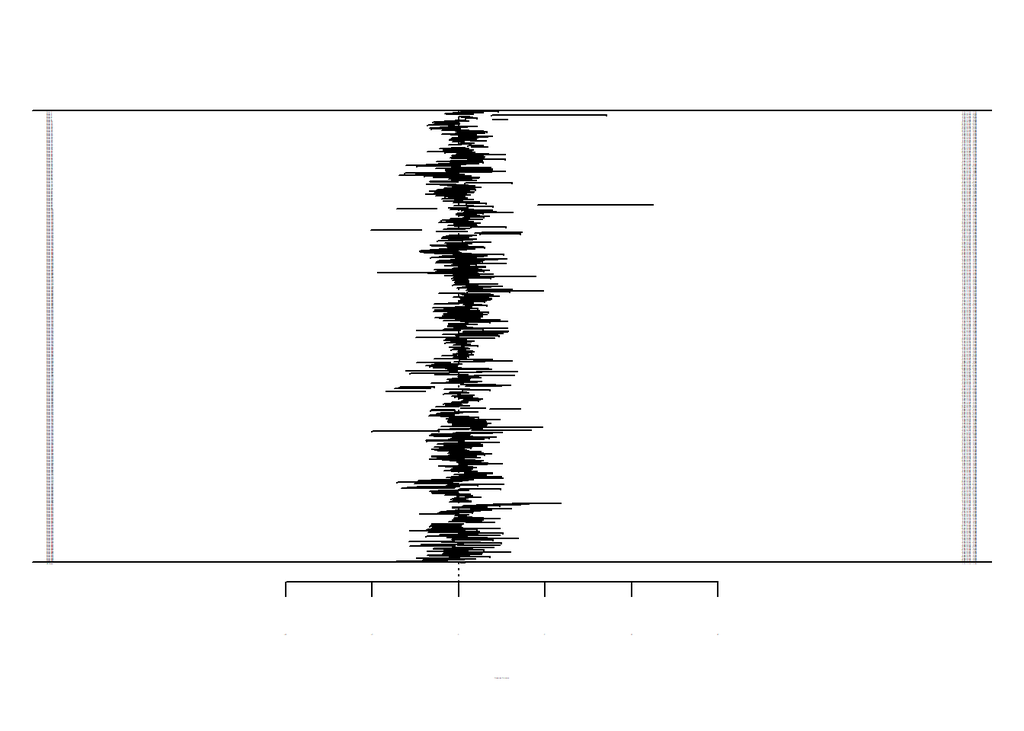

```r
# make a default forest plot
forest(meta.species.study.effectID)
```

### Figure S8

Forest plot showing the results of 459 effect sizes quantifying the animal bias (data from Lagisz et al., (2020)).

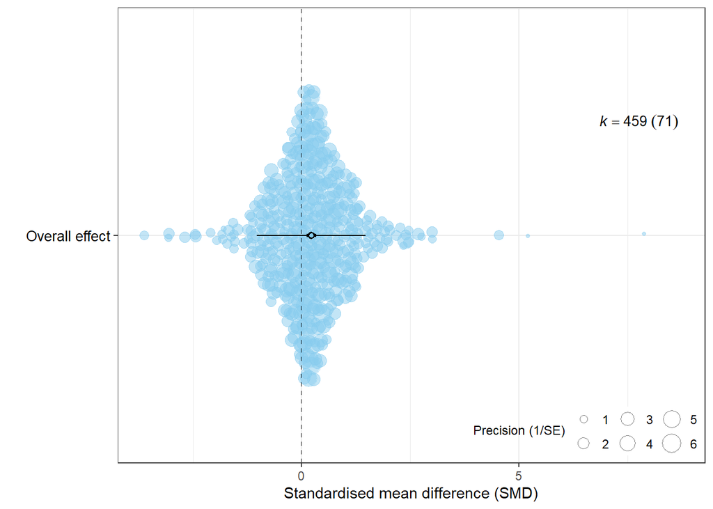

```r
# make a orchard plot
orchard_plot(meta.species.study.effectID, mod = "1", xlab = "Standardised mean difference (SMD)",
    group = "ArticleID", data = dat_cognition, k = TRUE, g = TRUE, transfm = "none",
    angle = 0) + scale_x_discrete(labels = c("Overall effect"))
```

### Figure S9

Orchard plot (forest-like plot) showing the results of 459 effect sizes quantifying the animal bias (data from Lagisz et al., (2020)). You can use help(orchard_plot) to look at the corresponding arguments and add more code to make it more elegant.

# 7. Fit multi-moderator multilevel meta-regression models

In this section, we use a more complex animal dataset to show how to select an appropriate random-effect structure, and therefore, to account for various types of non-independence and heterogeneity at different levels. This dataset comes from Lagisz et al., 2020, which examined cognition bias across 22 animal species using 71 studies with 459 effect sizes.

## 7.1 Concepts and rationale

Adding multiple moderators variables as fixed-effects leads to a multi-moderator multilevel meta-regression (i.e., multivariate meta-regression). In contrast to the single-moderator meta-regression (as illustrated early), a multi-moderator multilevel meta-regression can provide more neurobiological and meta-scientific insights, for example, (1) investigating the interactive effect between two moderator variables, and (2) correcting for publication bias and estimate the bias-adjusted effect size (Kvarven et al., 2020).

A more general form of multilevel meta-regression model can be written as:
$$ES_{[i]} = \beta_{0}' + \sum \beta_{mod}x_{[m]} + \mu_{between[j]} + \mu_{within[i]} + e_{[i]}, (12)\\ \mu_{between[j]} \sim N(0,\sigma_{between}^2)\\ \mu_{within[i]} \sim N(0,\sigma_{within}^2)\\ e_{[i]} \sim N(0,\nu_{[i]})$$

But for an easy start, let’s fit the simplest form of multi-moderator multilevel meta-regression model (two moderator variables without interactive term; see next section):
$$ES_{[i]} = \beta_{0}' + \beta_{1}x_{within[i]} + \beta_{2}x_{between[j]} + \mu_{between[j]} + \mu_{within[i]} + e_{[i]}, (14)\\ \mu_{between[j]} \sim N(0,\sigma_{between}^2)\\ \mu_{within[i]} \sim N(0,\sigma_{within}^2)\\ e_{[i]} \sim N(0,\nu_{[i]})$$

## 7.2 Fit a multilevel meta-regression to examine the interactive effects

Lagisz et al., 2020 has tested five moderator variables. We choose two of them for illustrative purpose:

**animal sex** (*Sex*) - sex of tested animals in the compared groups with three levels: female = only female animals were used; male = only male animals were used; both = both female and male animals were used.

**test task type** (*TaskType*) - type of the task used during behavioural trials with two levels: active choice = go/go tasks in which an animal is required to make an active response to cues perceived as positive and to cues perceived as negative; go/no-go = tasks in which an animal is required to suppress a response to cues perceived as negative and actively respond only to cues perceived as positive

By specifying argument `mods` with a formula of `~ Sex + TaskType -1` (I guess you still remember the trick of `-1`), we can fit a multivariate meta-regression model with these two moderators with:

```
maregression_sex.task <- rma.mv(yi = d,
                                V = Vd,
                                random = list(~ 1 | ArticleID, ~ 1 | EffectID),
                                mod = ~ Sex + TaskType -1, # model animal sex and test task type simultaneously;
                                data = dat_cognition,
                                method = 'REML', # remember to change the method used to estimate variance back to restricted maximum likelihood (REML);
                                sparse = TRUE)
```

```r
maregression_sex.task <- rma.mv(yi = d,
                                V = Vd,
                                random = list(~ 1 | ArticleID, ~ 1 | EffectID),
                                mod = ~ I(Sex) + I(TaskType) -1, # add animal sex and test task type simultaneously;
                                data = dat_cognition,
                                method = 'REML', # remember to change back to restricted maximum likelihood (REML);
                                sparse = TRUE)

summary(maregression_sex.task)
```

```
##
## Multivariate Meta-Analysis Model (k = 459; method: REML)
##
##    logLik   Deviance        AIC        BIC       AICc
## -563.4496  1126.8992  1138.8992  1163.6210  1139.0867
##
## Variance Components:
##
##             estim    sqrt  nlvls  fixed     factor
## sigma^2.1  0.1408  0.3752     71     no  ArticleID
## sigma^2.2  0.2614  0.5112    459     no   EffectID
##
## Test for Residual Heterogeneity:
## QE(df = 455) = 1438.1072, p-val < .0001
##
## Test of Moderators (coefficients 1:4):
## QM(df = 4) = 23.2763, p-val = 0.0001
##
## Model Results:
##
##                      estimate      se     zval    pval    ci.lb   ci.ub
## I(Sex)female           0.2303  0.1679   1.3718  0.1701  -0.0987  0.5593
## I(Sex)male             0.5488  0.1543   3.5559  0.0004   0.2463  0.8512  ***
## I(Sex)mixed-sex        0.3679  0.1726   2.1315  0.0330   0.0296  0.7062    *
## I(TaskType)go/no-go   -0.1609  0.1588  -1.0128  0.3112  -0.4722  0.1505
##
## ---
## Signif. codes:  0 '***' 0.001 '**' 0.01 '*' 0.05 '.' 0.1 ' ' 1
```

Under `Model Results`, we can see that for the moderator *Sex*, only “male” and “mixed-sex” show statistically significant effect on cognition bias ($\beta_{0}$ = 0.549, 95% CIs = [0.246 to 0.851] and $\beta_{0}$ = 0.368, 95% CIs = [0.030 to 0.706], respectively). Below we show that “female” also has statistically significant effect on cognition bias when controlling for the confounding effect of of *TaskType*.

Suppose that the relationship between animal sex and effect size estimates differs for different types of behavioral assay. We can test this hypothesis by modelling the interaction between the two moderator variables:
$$ES_{[i]} = \beta_{0}' + \beta_{1}x_{within[i]} + \beta_{2}x_{between[j]} + \beta_{3}x_{within[i]}x_{between[j]} + \mu_{between[j]} + \mu_{within[i]} + e_{[i]}, (12)\\ \mu_{between[j]} \sim N(0,\sigma_{between}^2)\\ \mu_{within[i]} \sim N(0,\sigma_{within}^2)\\ e_{[i]} \sim N(0,\nu_{[i]})$$
You can use the argument `mods` in `rma.mv()` to define the interaction between animal sex (*Sex*) and types of behavioral assay (*TaskType*). The core syntax is to use * to connect the two moderator variables (`mod = ~ Sex*TaskType -1`):

```
maregression_interaction <- rma.mv(yi = d,
                                V = Vd,
                                random = list(~ 1 | ArticleID, ~ 1 | EffectID),
                                mod = ~ Sex*TaskType -1, # model the interaction;
                                data = dat_cognition,
                                method = 'REML',
                                sparse = TRUE)
```

```r
# model the interactive effect between two moderator variables
maregression_interaction <- rma.mv(yi = d,
                                V = Vd,
                                random = list(~ 1 | ArticleID, ~ 1 | EffectID),
                                mod = ~ I(Sex)*I(TaskType) -1, # model animal sex and test task type simultaneously;
                                data = dat_cognition,
                                method = 'REML',
                                sparse = TRUE)
```

The outputs of the multilevel model with interaction term are similar to a “normal” meta-regression as shown early:

```r
summary(maregression_interaction)
```

```
##
## Multivariate Meta-Analysis Model (k = 459; method: REML)
##
##    logLik   Deviance        AIC        BIC       AICc
## -558.1527  1116.3055  1132.3055  1165.2326  1132.6298
##
## Variance Components:
##
##             estim    sqrt  nlvls  fixed     factor
## sigma^2.1  0.1294  0.3597     71     no  ArticleID
## sigma^2.2  0.2609  0.5108    459     no   EffectID
##
## Test for Residual Heterogeneity:
## QE(df = 453) = 1416.6432, p-val < .0001
##
## Test of Moderators (coefficients 1:6):
## QM(df = 6) = 30.5065, p-val < .0001
##
## Model Results:
##
##                                      estimate      se     zval    pval    ci.lb
## I(Sex)female                           0.7931  0.2853   2.7798  0.0054   0.2339
## I(Sex)male                             0.4613  0.1915   2.4091  0.0160   0.0860
## I(Sex)mixed-sex                        0.0331  0.2720   0.1218  0.9031  -0.5000
## I(TaskType)go/no-go                   -0.7752  0.2985  -2.5973  0.0094  -1.3601
## I(Sex)male:I(TaskType)go/no-go         0.7325  0.3724   1.9672  0.0492   0.0027
## I(Sex)mixed-sex:I(TaskType)go/no-go    1.0063  0.4194   2.3993  0.0164   0.1843
##                                        ci.ub
## I(Sex)female                          1.3522  **
## I(Sex)male                            0.8366   *
## I(Sex)mixed-sex                       0.5662
## I(TaskType)go/no-go                  -0.1902  **
## I(Sex)male:I(TaskType)go/no-go        1.4623   *
## I(Sex)mixed-sex:I(TaskType)go/no-go   1.8283   *
##
## ---
## Signif. codes:  0 '***' 0.001 '**' 0.01 '*' 0.05 '.' 0.1 ' ' 1
```

Under `Model Results`, now we see that “female” has a statistically significant effect on cognition bias ($\beta_{0}$ = 0.793, 95% CIs = [0.234 to 1.352]). Moreover, the last two lines provide the model estimates for the interactive effects. We can see that the interaction between animal sex and types of behavioral assay is statistically significant. The two moderator variables including their interaction can explain 10.6% variation among effect sizes (via `r2_ml` function).

```r
r2_ml(maregression_interaction)
```

```
##    R2_marginal R2_conditional
##      0.1063452      0.4026581
```

## 7.3 Correct for publication bias to estimate adjusted effect size

We have illustrated how to use univariate multilevel meta-regression to identify two forms of publication bias: small-study effect and decline effect (aka time-lag bias). A multi-moderator multilevel meta-regression with effect size’s sampling error ($se_{[i]}=\sqrt{\nu_{[i]}}$) and centred publication year ($c(year_{[i]})$; see below for explanations) can be used to correct for the impacts of the two forms of publication bias:
$$ES_{[i]} = \beta_{0}' + \beta_{1}se_{[i]} + \beta_{2}c(year_{[i]}) + \mu_{between[j]} + \mu_{within[i]} + e_{[i]}, (16)\\ \mu_{between[j]} \sim N(0,\sigma_{between}^2)\\ \mu_{within[i]} \sim N(0,\sigma_{within}^2)\\ e_{[i]} \sim N(0,\nu_{[i]})$$
We see that the intercept $\beta_{0}'$ shows the expected effect size estimate when the sampling error ($se_{[i]}=\sqrt{\nu_{[i]}}$) and centred publication year ($c(year_{[i]})$) of an effect size equal to zero. $se_{[i]}$ = 0 means the precision of an effect size is infinitely large (precision = $\frac {1} {se_{[i]}}$), which indicates there is no small-study effect. $c(year_{[i]})$ = 0 means there is no decline effect (i.e., time-lag bias). Therefore, intercept $\beta_{0}'$ can be interpreted as the publication-bias corrected effect size (Nakagawa et al., 2022; Stanley et al., 2017).

We can fit model 16 to Lagisz et al., 2020’s dataset with the syntax:

```
maregression_pb <- rma.mv(yi = d,
                          V = Vd,
                          random = list(~ 1 | ArticleID, ~ 1 | EffectID),
                          mod = ~ sed + Year.c, # sed = the sampling error (square root of sampling variance Vd); Year.c = the centered year (set mean year as 0), such that the model intercept is meaningful to be interpreted as a bias-corrected overall effect;
                          data = dat_cognition,
                          method = 'REML', # remember to change the method used to estimate variance back to restricted maximum likelihood (REML);
                          sparse = TRUE)
```

```r
# calculate the sampling error
dat_cognition$sed <- sqrt(dat_cognition$Vd)

# center the publication year, such that such that the intercept is meaningful to be interpreted as a bias-corrected overall effect
dat_cognition$Year.c <- scale(dat_cognition$Year, center = TRUE, scale = FALSE)

# add sampling error and centered year as fixed-effects terms to test and correct for publication bias
maregression_pb <- rma.mv(yi = d,
                          V = Vd,
                          random = list(~ 1 | ArticleID, ~ 1 | EffectID), mod = ~ sed + Year.c, # for continuous variable, do not need to remove intercept via "-1";
                          data = dat_cognition,
                          method = 'REML', # remember to change the method used to estimate variance back to restricted maximum likelihood (REML);
                          sparse = TRUE)
```

Under `Model Results`, `sed` and `Year.c` are the regression slopes of sampling error ($se_{[i]}=\sqrt{\nu_{[i]}}$) and publication year $c(year_{[i]})$: $\beta_{1}$ and $\beta_{2}$in model 16, respectively. We can see a statistically significant `sed` = 1.1561 (`p-value` = 0.0003), indicating there is a small-study effect (Figure S10). `Year.c` = -0.0002 is not statistically significant (`p-value` = 0.9931), suggesting that there is no decline effect (Figure S11).

```r
summary(maregression_pb)
```

```
##
## Multivariate Meta-Analysis Model (k = 459; method: REML)
##
##    logLik   Deviance        AIC        BIC       AICc
## -562.4264  1124.8529  1134.8529  1155.4653  1134.9862
##
## Variance Components:
##
##             estim    sqrt  nlvls  fixed     factor
## sigma^2.1  0.2012  0.4486     71     no  ArticleID
## sigma^2.2  0.2415  0.4914    459     no   EffectID
##
## Test for Residual Heterogeneity:
## QE(df = 456) = 1457.0561, p-val < .0001
##
## Test of Moderators (coefficients 2:3):
## QM(df = 2) = 12.8205, p-val = 0.0016
##
## Model Results:
##
##          estimate      se     zval    pval    ci.lb   ci.ub
## intrcpt   -0.2813  0.1566  -1.7957  0.0725  -0.5882  0.0257    .
## sed        1.1561  0.3232   3.5768  0.0003   0.5226  1.7897  ***
## Year.c    -0.0002  0.0217  -0.0087  0.9931  -0.0427  0.0423
##
## ---
## Signif. codes:  0 '***' 0.001 '**' 0.01 '*' 0.05 '.' 0.1 ' ' 1
```

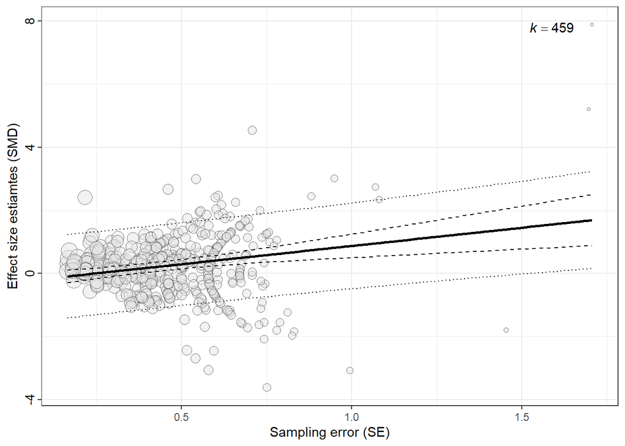

```r
# bubble plot showing the relationship between effect size and sampling error -
# small-study effect
bubble_plot(maregression_pb, mod = "sed", xlab = "Sampling error (SE)", ylab = "Effect size estiamtes (SMD)",
    group = "ArticleID", data = dat_cognition, legend.pos = "none")
```

### Figure S10

The relationship between effect size estimates (SMD) and their sampling error indicates a small-study effect.

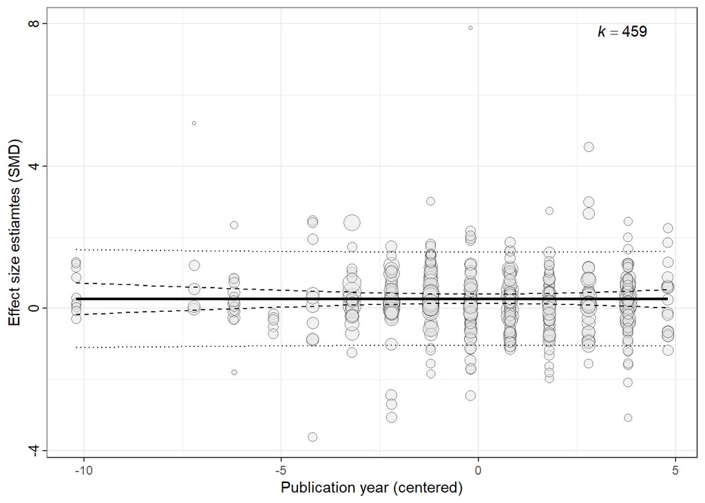

```r
# bubble plot showing the relationship between effect size and publication year
# - decline effect
bubble_plot(maregression_pb, mod = "Year.c", xlab = "Publication year (centered)",
    ylab = "Effect size estiamtes (SMD)", group = "ArticleID", data = dat_cognition,
    legend.pos = "none")
```

### Figure S11

The relationship between effect size estimates (SMD) and their publication year indicates no decline effect (time-lag bias).

One point of note here: simulation study indicates that $\beta_{0}'$ tends to underestimate the “true” effect (bias-corrected effect) if there is a nonzero treatment effect (i.e., $\beta_{0}'$ is statistically significant at the 10% significance level; Stanley et al., 2017). In such as a case, replacing the sampling error ($se_{[i]}=\sqrt{\nu_{[i]}}$) by its sampling variance ($se_{[i]}^2=\nu_{[i]}$) can reduce the bias of the estimated “true” effect (bias-corrected effect):
$$ES_{[i]} = \beta_{0}' + \beta_{1}se_{[i]}^2 + \beta_{2}c(year_{[i]}) + \mu_{between[j]} + \mu_{within[i]} + e_{[i]}, (17)\\ \mu_{between[j]} \sim N(0,\sigma_{between}^2)\\ \mu_{within[i]} \sim N(0,\sigma_{within}^2)\\ e_{[i]} \sim N(0,\nu_{[i]})$$
Given that $\beta_{0}'$ is statistically significant at the 10% significance level (`p-value` = 0.0725 < 0.1), we fit model 17 to correct for the publication bias:

```
maregression_pb2 <- rma.mv(yi = d,
                          V = Vd,
                          random = list(~ 1 | ArticleID, ~ 1 | EffectID),
                          mod = ~ Vd + Year.c, # repalcing sampling error (sed) by sampling variance (Vd) avoid downwardly biased estimate of the bias-corrected overall effect (i.e., model intercept);
                           data = dat_cognition,
                           method = 'REML',
                           sparse = TRUE)
```

```r
# replace sampling error by its variance
maregression_pb2 <- rma.mv(yi = d, V = Vd, random = list(~1 | ArticleID, ~1 | EffectID),
    mod = ~Vd + Year.c, data = dat_cognition, method = "REML", sparse = TRUE)
```

Let’s have a look at the model outputs:

```r
summary(maregression_pb2)
```

```
##
## Multivariate Meta-Analysis Model (k = 459; method: REML)
##
##    logLik   Deviance        AIC        BIC       AICc
## -560.1260  1120.2520  1130.2520  1150.8645  1130.3853
##
## Variance Components:
##
##             estim    sqrt  nlvls  fixed     factor
## sigma^2.1  0.1835  0.4284     71     no  ArticleID
## sigma^2.2  0.2456  0.4956    459     no   EffectID
##
## Test for Residual Heterogeneity:
## QE(df = 456) = 1455.6896, p-val < .0001
##
## Test of Moderators (coefficients 2:3):
## QM(df = 2) = 16.6698, p-val = 0.0002
##
## Model Results:
##
##          estimate      se     zval    pval    ci.lb   ci.ub
## intrcpt   -0.0060  0.0848  -0.0712  0.9432  -0.1723  0.1602
## Vd         1.0668  0.2616   4.0783  <.0001   0.5541  1.5795  ***
## Year.c     0.0003  0.0210   0.0120  0.9904  -0.0410  0.0415
##
## ---
## Signif. codes:  0 '***' 0.001 '**' 0.01 '*' 0.05 '.' 0.1 ' ' 1
```

`intrcpt` under `Model Results` is the estimate of model intercept ($\beta_{0}'$), indicating that the estimated bias-corrected overall effect is negligible ($\beta_{0}'$ = -0.006, 95% CIs = [-0.172 to 0.160], `p-value` = 0.943).

In our main text, we also mention that it is best to account for the potential heterogeneity when testing publication bias (because high heterogeneity may invalidate publication bias test):
$$ES_{[i]} = \beta_{0}' + \beta_{1}se_{[i]}^2 + \beta_{2}c(year_{[i]}) + \sum \beta_{mod}x_{[m]} + \mu_{between[j]} + \mu_{within[i]} + e_{[i]}, (18)\\ \mu_{between[j]} \sim N(0,\sigma_{between}^2)\\ \mu_{within[i]} \sim N(0,\sigma_{within}^2)\\ e_{[i]} \sim N(0,\nu_{[i]})$$
Such a complex model can be fitted with:

```
maregression_pb3 <- rma.mv(yi = d,
                           V = Vd,
                           random = list(~ 1 | ArticleID, ~ 1 | EffectID),
                           mod = ~ sed + Year.c + Sex + TaskType + CueTypeCat + ReinforcementCat -1, # add other important moderator variables to accommodate the potential heterogeneity in the dataset;
                           data = dat_cognition,
                           method = 'REML',
                           sparse = TRUE))
```

The regression slopes of sampling error ($se_{[i]}=\sqrt{\nu_{[i]}}$) and publication year $c(year_{[i]})$ have similar results with that without accounting for heterogeneity, although the exact values are different.

```r
# add other important moderator variables to accommodate the potential
# heterogeneity in the dataset
maregression_pb3 <- rma.mv(yi = d, V = Vd, random = list(~1 | ArticleID, ~1 | EffectID),
    mod = ~sed + Year.c + Sex + TaskType + CueTypeCat + ReinforcementCat - 1, data = dat_cognition,
    method = "REML", sparse = TRUE)
summary(maregression_pb3)
```

```
##
## Multivariate Meta-Analysis Model (k = 459; method: REML)
##
##    logLik   Deviance        AIC        BIC       AICc
## -545.5197  1091.0393  1119.0393  1176.4752  1120.0116
##
## Variance Components:
##
##             estim    sqrt  nlvls  fixed     factor
## sigma^2.1  0.2205  0.4696     71     no  ArticleID
## sigma^2.2  0.2391  0.4889    459     no   EffectID
##
## Test for Residual Heterogeneity:
## QE(df = 447) = 1411.0252, p-val < .0001
##
## Test of Moderators (coefficients 1:12):
## QM(df = 12) = 37.2702, p-val = 0.0002
##
## Model Results:
##
##                      estimate      se     zval    pval    ci.lb    ci.ub
## sed                    1.2319  0.3334   3.6946  0.0002   0.5784   1.8854  ***
## Year.c                 0.0123  0.0238   0.5165  0.6055  -0.0344   0.0590
## Sexfemale             -0.8188  0.3612  -2.2667  0.0234  -1.5268  -0.1108    *
## Sexmale               -0.4800  0.3480  -1.3791  0.1679  -1.1621   0.2022
## Sexmixed-sex          -0.6282  0.3666  -1.7135  0.0866  -1.3468   0.0904    .
## TaskTypego/no-go       0.2531  0.3004   0.8424  0.3995  -0.3357   0.8419
## CueTypeCatolfactory    0.1495  0.3845   0.3887  0.6975  -0.6041   0.9030
## CueTypeCatspatial     -0.0991  0.2345  -0.4225  0.6726  -0.5587   0.3605
## CueTypeCattactile      0.4913  0.3816   1.2875  0.1979  -0.2567   1.2393
## CueTypeCatvisual      -0.1417  0.2359  -0.6006  0.5481  -0.6041   0.3207
## ReinforcementCatR-P    0.2512  0.1731   1.4511  0.1468  -0.0881   0.5905
## ReinforcementCatR-R    0.3700  0.3182   1.1629  0.2449  -0.2536   0.9937
##
## ---
## Signif. codes:  0 '***' 0.001 '**' 0.01 '*' 0.05 '.' 0.1 ' ' 1
```

# 8. Construct variance-covariance matrix to account for correlated/non-independent error

As we shown in the main text, multiple effect sizes from the same study can result in two types of data non-independence: **non-independence between effect size estimates** (i.e., correlated effect size) and non-independence between sampling errors (i.e., correlated errors). The use of multilevel model with an appropriate random-effects structure can only capture the non-independence between effect size estimates. In this section, we show how to use a variance-covariance (VCV) matrix to capture the non-independence between sampling errors.

## 8.1 Concepts and rationale

Non-independence among sampling errors means sampling errors within the same study (e.g., $se_{1}$ and $se_{2}$) are correlated with each other ($\rho_{12}\neq0$), resulting non-zero covariances (e.g., $Cov[\nu_{1},\nu_{2}]=\rho_{12}se_{1}se_{2}$):

$$\boldsymbol{V} =
\begin{bmatrix}
se_{1}^2 & \rho_{12}se_{1}se_{2} & 0 \\
\rho_{12}se_{1}se_{2} & se_{2}^2 & 0 \\
0 & 0 & se_{3}^2
\end{bmatrix}, (19)$$
A rough rule can be used to check whether the sampling errors of your dataset are non-independent: when the calculation of effect sizes repeatedly uses the same animal data (e.g., shared control), the effect size’s sampling errors will be correlated with each other (see Figure 4 in the main text for a nice visual summary). If your dataset has this type of dependency, a proper way is to construct a VCV matrix to account for it. In reality, constructing a VCV matrix is often challenging because the within-study sampling correlation (e.g., $\rho_{12}$) are not reported in the primary animal studies. We provide a simple solution to construct a VCV matrix (see 8.2 for implementation).

## 8.2 Impute a VCV matrix

Although we are not able to exactly construct a VCV matrix (due to missing $\rho$), we can impute a VCV matrix by assuming a constant sampling correlation $\rho$ across different studies ($\rho_{ik}=\cdots=\rho_{jh}\equiv\rho$). In our previous published meta-analyses, we often assume $\rho$ to be 0.5, which seems to be a plausible and safe assumption across many situations (see the main text for explanations). Importantly, you should conduct a sensitivity analysis to explore the extent to which the model coefficients (e.g., $\beta_{0}$) are sensitive to the choice of $\rho$ values. The imputing of a VCV matrix can be implemented by `impute_covariance_matrix()` function in `clubSandwich`. The argument `cluster` is used to specify the cluster or grouping variable (in our case, study identity *ArticleID*) within which effect sizes’ sampling errors ($se_{[i]}=\sqrt{\nu_{[i]}}$) will be treated as correlated. The argument `r` is used to define the constant sampling correlation between $se_{[i]}$ ($\rho$).

```
VCV <- impute_covariance_matrix(vi = dat_cognition$Vd, # sampling variance;
                                cluster = dat_cognition$ArticleID, # define group variables;
                                r = 0.5)
```

```r
# assume that the effect sizes within studies are correlated with rho = 0.5
VCV <- impute_covariance_matrix(vi = dat_cognition$Vd, #
                                cluster = dat_cognition$ArticleID,
                                r = 0.5)
```

Have a loot at the constructed VCV matrix for studies Bateson et al., 2007 and Walker et al., 2014:

```r
# examine the VCV matrix for studies Bateson et al., 2007 and Walker et al.,
# 2014
VCV[dat_cognition$ArticleID %in% c("Bateson2007", "Walker2014"), dat_cognition$ArticleID %in%
    c("Bateson2007", "Walker2014")]
```

```
##            [,1]       [,2]       [,3]       [,4]      [,5]       [,6]
##  [1,] 0.3142764 0.12419993 0.11445591 0.11453637 0.4753658 0.00000000
##  [2,] 0.1241999 0.19633190 0.09046441 0.09052800 0.3757228 0.00000000
##  [3,] 0.1144559 0.09046441 0.16673417 0.08342569 0.3462457 0.00000000
##  [4,] 0.1145364 0.09052800 0.08342569 0.16696867 0.3464891 0.00000000
##  [5,] 0.4753658 0.37572275 0.34624569 0.34648909 2.8761009 0.00000000
##  [6,] 0.0000000 0.00000000 0.00000000 0.00000000 0.0000000 0.09573561
##  [7,] 0.0000000 0.00000000 0.00000000 0.00000000 0.0000000 0.04954690
##  [8,] 0.0000000 0.00000000 0.00000000 0.00000000 0.0000000 0.04481705
##  [9,] 0.0000000 0.00000000 0.00000000 0.00000000 0.0000000 0.04488780
## [10,] 0.0000000 0.00000000 0.00000000 0.00000000 0.0000000 0.04468489
##             [,7]       [,8]       [,9]      [,10]
##  [1,] 0.00000000 0.00000000 0.00000000 0.00000000
##  [2,] 0.00000000 0.00000000 0.00000000 0.00000000
##  [3,] 0.00000000 0.00000000 0.00000000 0.00000000
##  [4,] 0.00000000 0.00000000 0.00000000 0.00000000
##  [5,] 0.00000000 0.00000000 0.00000000 0.00000000
##  [6,] 0.04954690 0.04481705 0.04488780 0.04468489
##  [7,] 0.10256980 0.04638914 0.04646237 0.04625233
##  [8,] 0.04638914 0.08392147 0.04202698 0.04183699
##  [9,] 0.04646237 0.04202698 0.08418664 0.04190304
## [10,] 0.04625233 0.04183699 0.04190304 0.08342723
```

We can see that the VCV matrix is a block-diagonal covariance matrix, with the sampling variance ($se_{[i]}^2=\nu_{[i]}$) along the diagonal, and the covariance ($Cov[\nu_{i},\nu_{k}]=\rho_{ik}se_{i}se_{k}$) along the off-diagonal.

Next to re-run the multilevel intercept-only meta-analytic model using the constructed VCV matrix (*VCV*) with:

```
meta.study.effectID_VCV <- rma.mv(yi = d,
                                  V = VCV, # replace sampling variance with a vcv matrix
                                  random = list(~ 1 | ArticleID, ~ 1 | EffectID),
                                  data = dat_cognition,
                                  method = 'REML')
```

I guess you have already become familiar with the model outputs of `rma.mv()`:

```r
# run multilevel intetcept-only meta-analytic model without accounting for sampling covariance (correalted errors)
meta.study.effectID_var <- rma.mv(yi = d,
                                  V = Vd, # replace sampling variance with a vcv matrix
                                  random = list(~ 1 | ArticleID, ~ 1 | EffectID),
                                  data = dat_cognition,
                                  method = 'REML')

# re-run the multilevel intercept-only meta-analytic model with accounting for the sampling variance using the constructed VCV matrix with rho = 0.5 - medium correlation
meta.study.effectID_VCV <- rma.mv(yi = d,
                                  V = VCV, # replace sampling variance with a vcv matrix
                                  random = list(~ 1 | ArticleID, ~ 1 | EffectID),
                                  data = dat_cognition,
                                  method = 'REML')

# show the model outputs of the re-ran model
summary(meta.study.effectID_VCV)
```

```
##
## Multivariate Meta-Analysis Model (k = 459; method: REML)
##
##    logLik   Deviance        AIC        BIC       AICc
## -584.4066  1168.8133  1174.8133  1187.1939  1174.8661
##
## Variance Components:
##
##             estim    sqrt  nlvls  fixed     factor
## sigma^2.1  0.0000  0.0001     71     no  ArticleID
## sigma^2.2  0.4469  0.6685    459     no   EffectID
##
## Test for Heterogeneity:
## Q(df = 458) = 2127.6189, p-val < .0001
##
## Model Results:
##
## estimate      se    zval    pval   ci.lb   ci.ub
##   0.1961  0.0516  3.8020  0.0001  0.0950  0.2972  ***
##
## ---
## Signif. codes:  0 '***' 0.001 '**' 0.01 '*' 0.05 '.' 0.1 ' ' 1
```

```r
meta.study.effectID_VCV0.5 <- meta.study.effectID_VCV

# re-run the multilevel intercept-only meta-analytic model with accounting for the sampling variance using the constructed VCV matrix with rho = 0.2 - small correlation
VCV0.2 <- impute_covariance_matrix(vi = dat_cognition$Vd, #
                                cluster = dat_cognition$ArticleID,
                                r = 0.2)
meta.study.effectID_VCV0.2 <- rma.mv(yi = d,
                                  V = VCV0.2,
                                  random = list(~ 1 | ArticleID, ~ 1 | EffectID),
                                  data = dat_cognition,
                                  method = 'REML')

# re-run the multilevel intercept-only meta-analytic model with accounting for the sampling variance using the constructed VCV matrix with rho = 0.2 - small correlation
VCV0.7 <- impute_covariance_matrix(vi = dat_cognition$Vd, #
                                cluster = dat_cognition$ArticleID,
                                r = 0.7)
meta.study.effectID_VCV0.7 <- rma.mv(yi = d,
                                  V = VCV0.7,
                                  random = list(~ 1 | ArticleID, ~ 1 | EffectID),
                                  data = dat_cognition,
                                  method = 'REML')
```

Nice! The overall effect ($\beta_{0}$ = 0.1961, 95% CIs = [0.095 to 0.297], `p-value` = 0.0001) remains statistically significant after accounting for the covariance between effect sizes (i.e., correlated errors). Moreover, sensitivity analysis shows that the model estimates are robust to different values of $\rho$ (Table S5).

### Table S5

The use of sensitivity analysis to examine the sensitivity of model estimates to the choice of $\rho$ values.

```r
t5 <- data.frame(`Sampling correlation (ρ)` = c("Small correlation (0.2)", "Medium correlation (0.5)",
    "Large correlation (0.7)"), `Overall effect` = c(round(meta.study.effectID_VCV0.2$b[1],
    2), round(meta.study.effectID_VCV0.5$b[1], 2), round(meta.study.effectID_VCV0.7$b[1],
    2)), `Standard error` = c(round(meta.study.effectID_VCV0.2$se, 2), round(meta.study.effectID_VCV0.5$se,
    2), round(meta.study.effectID_VCV0.7$se, 2)), `p-value` = c(round(meta.study.effectID_VCV0.2$pval,
    3), round(meta.study.effectID_VCV0.5$pval, 3), round(meta.study.effectID_VCV0.7$pval,
    3)), `Lower CI` = c(round(meta.study.effectID_VCV0.2$ci.lb, 2), round(meta.study.effectID_VCV0.5$ci.lb,
    2), round(meta.study.effectID_VCV0.7$ci.lb, 2)), `Upper CI` = c(round(meta.study.effectID_VCV0.2$ci.ub,
    2), round(meta.study.effectID_VCV0.5$ci.ub, 2), round(meta.study.effectID_VCV0.7$ci.ub,
    2)))

names(t5) <- c("Sampling correlation (ρ)", "Overall effect", "Standard error", "p-value",
    "Lower CI", "Upper CI")

kable(t(t5))
```

| Sampling correlation (ρ) | Small correlation (0.2) | Medium correlation (0.5) | Large correlation (0.7) |
| --- | --- | --- | --- |
| Overall effect | 0.21 | 0.20 | 0.19 |
| Standard error | 0.05 | 0.05 | 0.06 |
| p-value | 0.000 | 0.000 | 0.001 |
| Lower CI | 0.11 | 0.10 | 0.08 |
| Upper CI | 0.32 | 0.30 | 0.30 |

# 9. Make cluster-robust model inferences

## 9.1 Concepts and rationale

There is an alternative method to account for handle statistical non-independence:variance estimation method (REV). As shown above, the multilevel model uses a multilevel random-effects structure to account for non-independence among effect sizes and a VCV matrix to account for non-independence among sampling errors. In contrast, REV does can estimate the sampling covariances from the meta-analytic data and subsequently adjust the associated standard errors (a so-called robust standard errors) to avoid inflated Type I error and p-value of model coefficients (e.g., overall effect: $\beta_{0}$).

## 9.2 Meta-analysis with RVE with the multilevel model framework

Some researchers recommend using the multilevel model to account for data non-independence, while others endorse the use of RVE. Rather than choosing between the two, we prefer to take advantages of both (a so-called hybrid strategy): implementing a multilevel model in the framework of RVE. By doing so, RVE can provide us with the robust significance tests and confidence intervals for the model coefficients. Meanwhile, the multilevel model can provide us with extral model estimates, for example, the partition of variance components across levels (e.g., $\sigma_{between}^2$ and $\sigma_{within}^2$). This hybrid strategy seems very difficult to implement. Luck thing is the combination of `metafor` and `clubSandwich` packages provides an elegant solution to it.

The implementation is very straightforward. First to construct a multilevel meta-analytic model via `rma.mv()` function in `metafor` package:

```
multilevl.ma.model <- rma.mv(yi = d,
                             V = Vd,
                             random = list(~ 1 | ArticleID, ~ 1 | EffectID),
                             data = dat_cognition,
                             method = 'REML')
```

Then, use `coef_test()` function in `clubSandwich` package to compute the robust error and use it for the subsequent model inferences (i.e., significance tests):

```
mod_RVE <- coef_test(multilevl.ma.model, # fitted multilevel model for which to make robust model inference (an object of class "rma.mv");
                     vcov = "CR2", # ‘bias-reduced linearization’ is specified to approximate variance-covariance;
                     test="Satterthwaite", # method for which small-sample correction to approximate;
                     cluster = dat_cognition$ArticleID
                     )
```

As shown below, the outputs of the `coef_test()` function mainly focus on the model inferences - significance tests of the model coefficient (e.g., $\beta_{0}$):

```r
# construct a multilevel meta-analytic model
multilevl.ma.model <- rma.mv(yi = d,
                             V = Vd,
                             random = list(~ 1 | ArticleID, ~ 1 | EffectID),
                             data = dat_cognition,
                             method = 'REML')

# make robust model inferences
mod_RVE <- coef_test(multilevl.ma.model, # fitted multilevel model for which to make robust model inference (an object of class "rma.mv");
                     vcov = "CR2", # ‘bias-reduced linearization’ is specified to approximate variance-covariance;
                     test="Satterthwaite", # method for which small-sample correction to approximate;
                     cluster = dat_cognition$ArticleID
                     )
print(mod_RVE)
```

```
##     Coef. Estimate     SE t-stat d.f. p-val (Satt) Sig.
## 1 intrcpt    0.226 0.0581   3.88 65.8       <0.001  ***
```

# Software and package versions

```r
sessionInfo() %>%
    pander()
```

**R version 4.0.3 (2020-10-10)**

**Platform:** x86_64-w64-mingw32/x64 (64-bit)

**locale:** _LC_COLLATE=Chinese (Simplified)*China.936*, _LC_CTYPE=Chinese (Simplified)*China.936*, _LC_MONETARY=Chinese (Simplified)*China.936*, *LC_NUMERIC=C* and _LC_TIME=Chinese (Simplified)*China.936*

**attached base packages:** *grid*, *stats*, *graphics*, *grDevices*, *utils*, *datasets*, *methods* and *base*

**other attached packages:** *formatR(v.1.11)*, *pander(v.0.6.4)*, *gridGraphics(v.0.5-1)*, *png(v.0.1-7)*, *cowplot(v.1.1.1)*, *ggthemr(v.1.1.0)*, *ggalluvial(v.0.12.3)*, *visdat(v.0.5.3)*, *ggsignif(v.0.6.3)*, *networkD3(v.0.4)*, *GoodmanKruskal(v.0.0.3)*, *patchwork(v.1.1.1)*, *MuMIn(v.1.43.17)*, *orchaRd(v.2.0)*, *clubSandwich(v.0.5.3)*, *metafor(v.3.4-0)*, *metadat(v.1.2-0)*, *Matrix(v.1.2-18)*, *readxl(v.1.3.1)*, *DT(v.0.19)*, *here(v.1.0.1)*, *knitr(v.1.37)*, *forcats(v.0.5.1)*, *stringr(v.1.4.0)*, *dplyr(v.1.0.7)*, *purrr(v.0.3.4)*, *readr(v.2.0.1)*, *tidyr(v.1.1.3)*, *tibble(v.3.1.4)*, *ggplot2(v.3.3.5)* and *tidyverse(v.1.3.1)*

**loaded via a namespace (and not attached):** *TH.data(v.1.1-0)*, *ggbeeswarm(v.0.6.0)*, *colorspace(v.2.0-0)*, *ellipsis(v.0.3.2)*, *rprojroot(v.2.0.2)*, *estimability(v.1.3)*, *fs(v.1.5.0)*, *rstudioapi(v.0.13)*, *farver(v.2.1.0)*, *fansi(v.0.5.0)*, *mvtnorm(v.1.1-2)*, *lubridate(v.1.7.10)*, *mathjaxr(v.1.2-0)*, *xml2(v.1.3.2)*, *codetools(v.0.2-18)*, *splines(v.4.0.3)*, *jsonlite(v.1.7.2)*, *broom(v.0.7.9)*, *dbplyr(v.2.1.1)*, *latex2exp(v.0.9.4)*, *compiler(v.4.0.3)*, *httr(v.1.4.2)*, *emmeans(v.1.6.3)*, *backports(v.1.2.1)*, *assertthat(v.0.2.1)*, *fastmap(v.1.1.0)*, *cli(v.3.0.1)*, *htmltools(v.0.5.2)*, *tools(v.4.0.3)*, *igraph(v.1.2.6)*, *coda(v.0.19-4)*, *gtable(v.0.3.0)*, *glue(v.1.4.2)*, *Rcpp(v.1.0.6)*, *cellranger(v.1.1.0)*, *jquerylib(v.0.1.4)*, *vctrs(v.0.3.8)*, *nlme(v.3.1-151)*, *crosstalk(v.1.1.1)*, *xfun(v.0.29)*, *rvest(v.1.0.1)*, *lifecycle(v.1.0.0)*, *pacman(v.0.5.1)*, *MASS(v.7.3-54)*, *zoo(v.1.8-9)*, *scales(v.1.1.1)*, *hms(v.1.1.0)*, *sandwich(v.3.0-1)*, *yaml(v.2.2.1)*, *sass(v.0.4.0)*, *stringi(v.1.7.4)*, *highr(v.0.9)*, *rlang(v.0.4.10)*, *pkgconfig(v.2.0.3)*, *evaluate(v.0.14)*, *lattice(v.0.20-41)*, *htmlwidgets(v.1.5.3)*, *labeling(v.0.4.2)*, *tidyselect(v.1.1.1)*, *plyr(v.1.8.6)*, *magrittr(v.2.0.1)*, *R6(v.2.5.1)*, *generics(v.0.1.0)*, *multcomp(v.1.4-17)*, *DBI(v.1.1.1)*, *mgcv(v.1.8-33)*, *pillar(v.1.6.2)*, *haven(v.2.4.3)*, *withr(v.2.4.2)*, *survival(v.3.2-7)*, *modelr(v.0.1.8)*, *crayon(v.1.4.1)*, *utf8(v.1.2.2)*, *tzdb(v.0.1.2)*, *rmarkdown(v.2.11)*, *reprex(v.2.0.1)*, *digest(v.0.6.27)*, *xtable(v.1.8-4)*, *stats4(v.4.0.3)*, *munsell(v.0.5.0)*, *beeswarm(v.0.4.0)*, *vipor(v.0.4.5)* and *bslib(v.0.3.0)*